# PSC study: Q2

##### Visualization

Heatmap visualizing the linDA’s logFoldChange for taxa with p < 0.1.

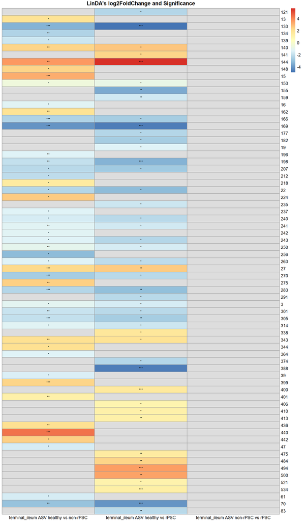

```r
list_heatmap <- list_intersections[grep(paste(segment,level),
                                  names(list_intersections),value=TRUE)]

p_heatmap_linda <- heatmap_linda(list_heatmap,ileum_taxa_tab)
p_heatmap_linda
```

Dotheatmap

```r
dotheatmap_linda <- dot_heatmap_linda(list_heatmap,
                                      uni_statistics$terminal_ileum[grepl(level,names(uni_statistics$terminal_ileum))],
                                      ileum_taxa_tab)
```

```
## min_clr -0.9733804
## max_clr 4.946497
## min_log -4.9062
## max_log 5.67034
```

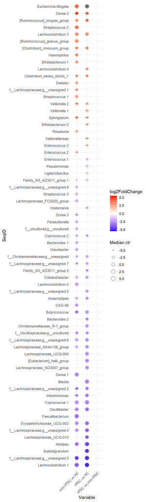

```r
dotheatmap_linda
```

##### rPSC effect

**pre_LTx vs Healthy and Post_LTx vs Healthy intersection**

```r
A <- list_intersections[[paste(segment,level,"healthy vs rPSC")]]
B <- list_intersections[[paste(segment,level,"healthy vs non-rPSC")]]
df <- A[!(A$SeqID %in% B$SeqID),]


rpsc_effect[[paste(segment,level)]] <- df

# see the results
rpsc_effect[[paste(segment,level)]]
```

|  | SeqID | Taxonomy | log2FoldChange | p_value | padj |
| --- | --- | --- | --- | --- | --- |
| 19 | TAGGGAATTTTCGGCAATGGGCGAAAGCCTGACCGAGCAACGCCGCGTGAGTGAAGAAGG…… | k__Bacteria;p__Firmicutes;c__Bacilli;o__Erysipelotrichales;f__Erysipelotrichaceae;g__Holdemania;s__unassigned | -1.3555889 | 4.725024e-03 | 0.0475938770 |
| 83 | TGAGGAATATTGGTCAATGGGCGAGAGCCTGAACCAGCCAAGTAGCGTGAAGGATGAAGG…… | k__Bacteria;p__Bacteroidota;c__Bacteroidia;o__Bacteroidales;f__Bacteroidaceae;g__Bacteroides;s__unassigned | -2.1838725 | 7.778840e-05 | 0.0026934234 |
| 121 | TGGGGAATATTGCACAATGGAGGAAACTCTGATGCAGCGACGCCGCGTGAGTGAAGAAGT…… | k__Bacteria;p__Firmicutes;c__Clostridia;o__Lachnospirales;f__Lachnospiraceae;g__Lachnospiraceae_ND3007_group;s__unassigned | -2.3280429 | 3.462916e-03 | 0.0399678225 |
| 141 | TGGGGAATATTGCACAATGGGCGAAAGCCTGATGCAGCGACGCCGCGTGAGTGAAGAAGT…… | k__Bacteria;p__Firmicutes;c__Clostridia;o__Lachnospirales;f__Lachnospiraceae;g__Lachnoclostridium;s__unassigned | 2.3085811 | 3.044134e-03 | 0.0374766680 |
| 155 | TGGGGAATATTGCACAATGGGGGAAACCCTGATGCAGCAACGCCGCGTGAAGGAAGAAGG…… | k__Bacteria;p__Firmicutes;c__Clostridia;o__Lachnospirales;f__Lachnospiraceae;g__Lachnospiraceae_UCG-010;s__unassigned | -3.5338892 | 3.308601e-05 | 0.0014795060 |
| 159 | TGGGGAATATTGCACAATGGGGGAAACCCTGATGCAGCAACGCCGCGTGAAGGATGAAGG…… | k__Bacteria;p__Firmicutes;c__Clostridia;o__Peptostreptococcales-Tissierellales;f__Anaerovoracaceae;g__Family_XIII_AD3011_group;s__unassigned | -1.6310101 | 1.616354e-04 | 0.0047129473 |
| 177 | TGGGGAATATTGCACAATGGGGGAAACCCTGATGCAGCAACGCCGCGTGAGTGAAGAAGT…… | k__Bacteria;p__Firmicutes;c__Clostridia;o__Lachnospirales;f__Lachnospiraceae;g__[Eubacterium]_hallii_group;s__unassigned | -2.3243741 | 5.048810e-03 | 0.0490708929 |
| 182 | TGGGGAATATTGCACAATGGGGGAAACCCTGATGCAGCGACGCCGCGTGAAGGAAGAAGT…… | k__Bacteria;p__Firmicutes;c__Clostridia;o__Lachnospirales;f__Lachnospiraceae;g__Blautia;s__unassigned | -2.6614071 | 2.580482e-03 | 0.0340377832 |
| 235 | TGGGGAATATTGCACAATGGGGGAAACCCTGATGCAGCGACGCCGCGTGAGTGAAGAAGT…… | k__Bacteria;p__Firmicutes;c__Clostridia;o__Lachnospirales;f__Lachnospiraceae;g__unassigned;s__unassigned | -1.8154848 | 2.571507e-03 | 0.0340377832 |
| 291 | TGGGGAATATTGGGCAATGGGCGAAAGCCTGACCCAGCAACGCCGCGTGAGGGAAGAAGG…… | k__Bacteria;p__Firmicutes;c__Clostridia;o__Christensenellales;f__Christensenellaceae;g__Christensenellaceae_R-7_group;s__unassigned | -2.1850923 | 1.606404e-03 | 0.0247207797 |

[output cut: 9 more lines]

#### Phylum level

```r
level="phylum"

# needed path
path_maaslin="../intermediate_files/maaslin/Q2/Phylum/"

# variables
raw_linda_results_phylum <- list();
raw_linda_results_phylum[[segment]] <- list()
linda_results_phylum <- list();
linda_results_phylum[[segment]] <- list()
```

Aggregate taxa

```r
phylum_data <- aggregate_taxa(ileum_asv_tab,
                             ileum_taxa_tab,
                             taxonomic_level = "Phylum")

ileum_phylum_tab <- phylum_data[[1]]
ileum_phylum_taxa_tab <- phylum_data[[2]]
```

##### rPSC vs non-rPSC

```r
group <- c("non-rPSC","rPSC")
comparison_name <- paste0(group[1], " vs ",group[2])
```

**linDA**

```r
# prepare the data
linda_data <- binomial_prep(ileum_phylum_tab,
                            ileum_phylum_taxa_tab,
                            ileum_metadata,
                            group, usage="linDA")
```

```
## Removing 3 ASV(s)
```

```r
filt_ileum_uni_data <- linda_data[[1]]
filt_ileum_uni_taxa <- linda_data[[2]]
filt_ileum_uni_metadata <- linda_data[[3]]

# fit the model
linda.obj <- linda(filt_ileum_uni_data,
                   filt_ileum_uni_metadata,
                   formula = '~ Group * Country')
```

```
## 0  features are filtered!
## The filtered data has  138  samples and  11  features will be tested!
## Imputation approach is used.
## Fit linear models ...
## Completed.
```

```r
linda.output <- linda.obj$output
linda.output <- linda_renaming(linda.output, group)

# save the results
group1 <- paste0(group[1], " vs ","Group",group[2])
group2 <- paste0(group[1], " , ",group[2], " - CZ vs NO")
group3 <- paste0(group[1], " vs ","Group",group[2], ":CountryNO")

for (grp in c(group1,group2,group3)){
  raw_linda_results_phylum[[segment]][[grp]] <-
    rawlinda.df(linda.output,
                grp,
                filt_ileum_uni_data,
                filt_ileum_uni_taxa)

  linda_results_phylum[[segment]][[grp]] <-
    linda.df(linda.output,
             grp,
             filt_ileum_uni_data,
             filt_ileum_uni_taxa)
}
```

```r
# volcano plot
volcano_1 <- volcano_plot_linda(linda.output,
                                group1,
                                taxa_table = filt_ileum_uni_taxa) +
            ggtitle(comparison_title)
```

```
## Using Phylum for naming
```

```r
volcano_2  <- volcano_plot_linda(linda.output, group2,
                                taxa_table = filt_ileum_uni_taxa) +
            ggtitle("NO vs CZ")
```

```
## Using Phylum for naming
```

```r
volcano_3 <- volcano_plot_linda(linda.output, group3,
                                taxa_table = filt_ileum_uni_taxa) +
            ggtitle("Interaction effect")
```

```
## Using Phylum for naming
```

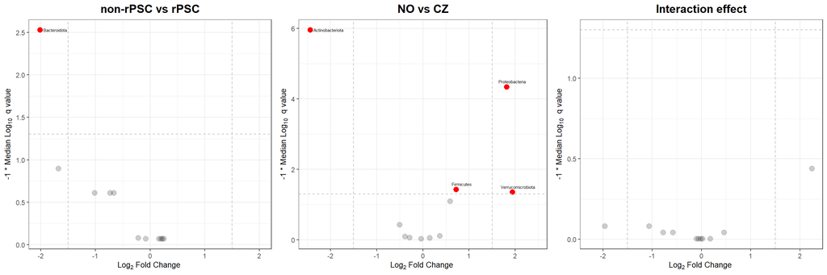

```r
volcano <- ggarrange(volcano_1,volcano_2,volcano_3, ncol=3)
volcano
```

**MaAsLin2**

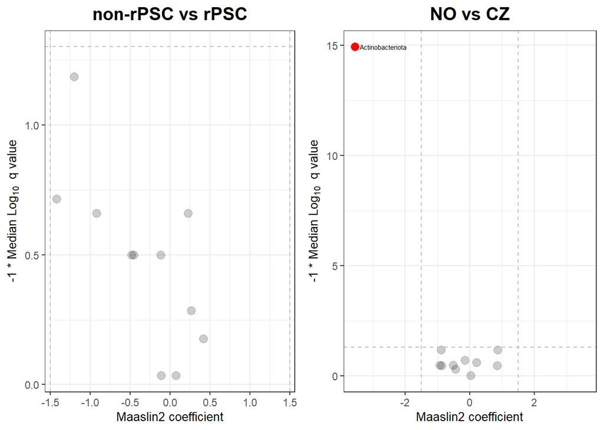

```r
volcano1 <- volcano_plot_maaslin(fit_data,filt_ileum_uni_taxa) +
            ggtitle(comparison_title)

volcano2 <- volcano_plot_maaslin(fit_data,filt_ileum_uni_taxa,variable="Country") +
            ggtitle("NO vs CZ")

volcano <- ggarrange(volcano1,volcano2, ncol=2)
volcano
```

**Group - Intersection**

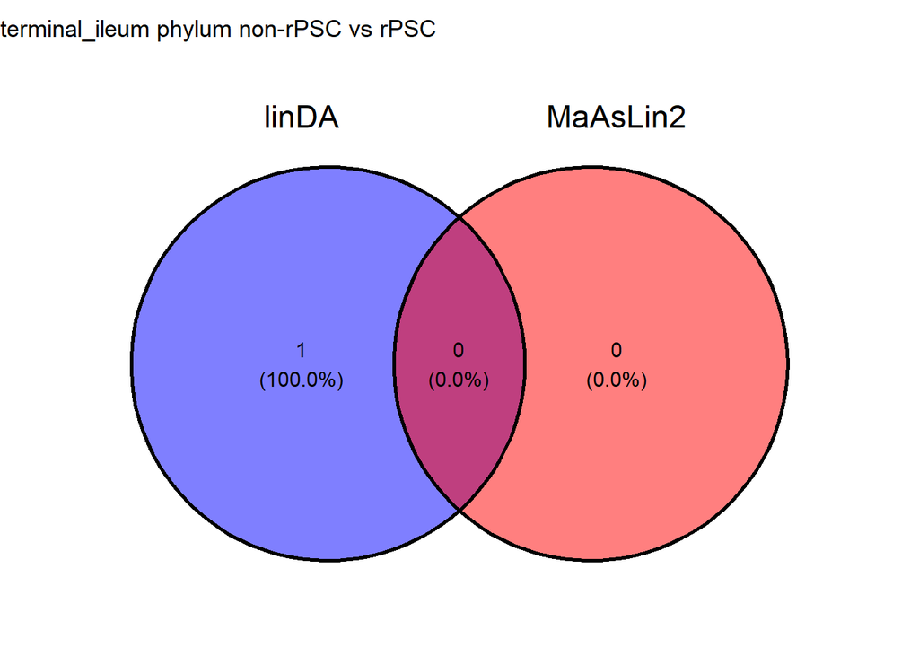

```r
intersection_results <- group_intersection(group, list_intersections, list_venns,
                                           linda.output, fit_data,
                                           raw_linda_results_phylum,
                                           segment = segment,
                                           level=level)

list_intersections <- intersection_results[[1]]
list_venns <- intersection_results[[2]]
venn <- intersection_results[[3]]

# show the results
venn
```

Interaction effect

```r
list_interaction_significant <- country_interaction(group,
                                                    linda.output,
                                                    list_intersections,
                                          filt_ileum_uni_data,
                                          filt_ileum_uni_metadata,
                                          segment=segment,
                                          level=level)

# see the result
## significant interaction effect
list_interaction_significant[[1]]
```

```r
## results for czech cohort
list_interaction_significant[[2]]
```

```
## [1] NA
```

```r
## results for norwegian cohort
list_interaction_significant[[3]]
```

```
## [1] NA
```

Removing problematic taxa

```r
list_intersections <- removing_interaction_problems(group,
                                                    list_interaction_significant,
                                                    list_intersections,
                                                    segment=segment,
                                                    level=level)
```

**Basic statistics**

```r
uni_df <-  merge(basic_univariate_statistics(linda_data,group),
                 raw_linda_results_phylum[[segment]][[group1]],
                 by="SeqID",all=TRUE)
```

```
## [1] "non-rPSC"
## [1] "rPSC"
## [1] "non-rPSC"
## [1] "rPSC"
```

```r
uni_df[["final_sig"]] <- uni_df$SeqID %in% list_intersections[[paste(segment,level,comparison_name)]][["SeqID"]]
uni_statistics[[segment]][[paste(level,comparison_name)]] <- uni_df

# for comparison
new_name <- paste(level,comparison_name)
addWorksheet(supplements_wb, sheetName = new_name)
writeData(supplements_wb, sheet = new_name, uni_df, rowNames=FALSE)
```

##### rPSC vs healthy

```r
group <- c("rPSC","healthy")
comparison_name <- paste0(group[1], " vs ",group[2])
```

**linDA**

```r
# prepare the data
linda_data <- binomial_prep(ileum_phylum_tab,
                            ileum_phylum_taxa_tab,
                            ileum_metadata,
                            group, usage="linDA")
```

```
## Removing 2 ASV(s)
```

```r
filt_ileum_uni_data <- linda_data[[1]]
filt_ileum_uni_taxa <- linda_data[[2]]
filt_ileum_uni_metadata <- linda_data[[3]]

# fit the model
linda.obj <- linda(filt_ileum_uni_data,
                   filt_ileum_uni_metadata,
                   formula = '~ Group * Country')
```

```
## 0  features are filtered!
## The filtered data has  106  samples and  11  features will be tested!
## Imputation approach is used.
## Fit linear models ...
## Completed.
```

```r
linda.output <- linda.obj$output
linda.output <- linda_renaming(linda.output, group)

# save the results
group1 <- paste0(group[1], " vs ","Group",group[2])
group2 <- paste0(group[1], " , ",group[2], " - CZ vs NO")
group3 <- paste0(group[1], " vs ","Group",group[2], ":CountryNO")

for (grp in c(group1,group2,group3)){
  raw_linda_results_phylum[[segment]][[grp]] <-
    rawlinda.df(linda.output,
                grp,
                filt_ileum_uni_data,
                filt_ileum_uni_taxa)

  linda_results_phylum[[segment]][[grp]] <-
    linda.df(linda.output,
             grp,
             filt_ileum_uni_data,
             filt_ileum_uni_taxa)
}
```

```r
# volcano plot
volcano_1 <- volcano_plot_linda(linda.output,
                                group1,
                                taxa_table = filt_ileum_uni_taxa) +
            ggtitle(comparison_title)
```

```
## Using Phylum for naming
```

```r
volcano_2  <- volcano_plot_linda(linda.output, group2,
                                taxa_table = filt_ileum_uni_taxa) +
            ggtitle("NO vs CZ")
```

```
## Using Phylum for naming
```

```r
volcano_3 <- volcano_plot_linda(linda.output, group3,
                                taxa_table = filt_ileum_uni_taxa) +
            ggtitle("Interaction effect")
```

```
## Using Phylum for naming
```

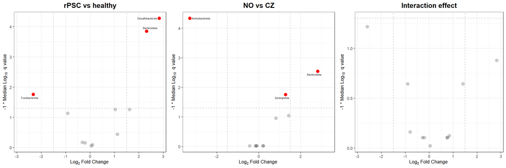

```r
volcano <- ggarrange(volcano_1,volcano_2,volcano_3, ncol=3)
volcano
```

**MaAsLin2**

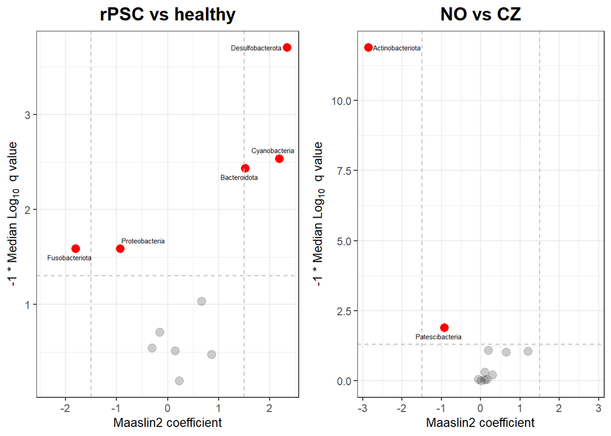

```r
volcano1 <- volcano_plot_maaslin(fit_data,filt_ileum_uni_taxa) +
            ggtitle(comparison_title)

volcano2 <- volcano_plot_maaslin(fit_data,filt_ileum_uni_taxa,variable="Country") +
            ggtitle("NO vs CZ")

volcano <- ggarrange(volcano1,volcano2, ncol=2)
volcano
```

**Group - Intersection**

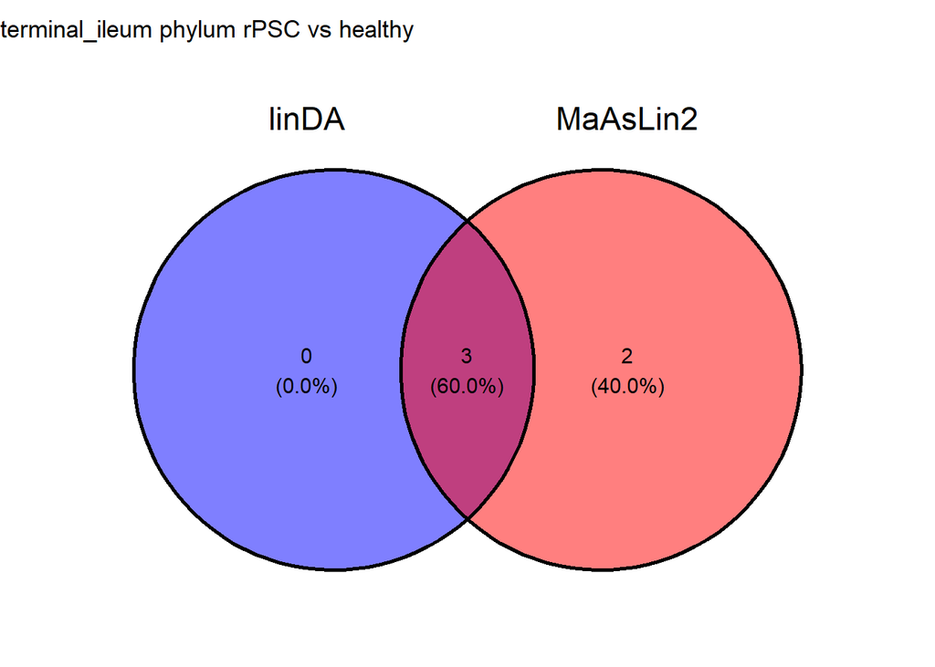

```r
intersection_results <- group_intersection(group, list_intersections, list_venns,
                                           linda.output, fit_data,
                                           raw_linda_results_phylum,
                                           segment = segment,
                                           level=level)

list_intersections <- intersection_results[[1]]
list_venns <- intersection_results[[2]]
venn <- intersection_results[[3]]

# show the results
venn
```

Interaction effect

```r
list_interaction_significant <- country_interaction(group,
                                                    linda.output,
                                                    list_intersections,
                                          filt_ileum_uni_data,
                                          filt_ileum_uni_metadata,
                                          segment=segment,
                                          level=level)

# see the result
## significant interaction effect
list_interaction_significant[[1]]
```

```r
## results for czech cohort
list_interaction_significant[[2]]
```

```
## [1] NA
```

```r
## results for norwegian cohort
list_interaction_significant[[3]]
```

```
## [1] NA
```

Removing problematic taxa

```r
list_intersections <- removing_interaction_problems(group,
                                                    list_interaction_significant,
                                                    list_intersections,
                                                    segment=segment,
                                                    level=level)
```

**Basic statistics**

```r
uni_df <-  merge(basic_univariate_statistics(linda_data,group),
                 raw_linda_results_phylum[[segment]][[group1]],
                 by="SeqID",all=TRUE)
```

```
## [1] "rPSC"
## [1] "healthy"
## [1] "rPSC"
## [1] "healthy"
```

```r
uni_df[["final_sig"]] <- uni_df$SeqID %in% list_intersections[[paste(segment,level,comparison_name)]][["SeqID"]]
uni_statistics[[segment]][[paste(level,comparison_name)]] <- uni_df

# for comparison
new_name <- paste(level,comparison_name)
addWorksheet(supplements_wb, sheetName = new_name)
writeData(supplements_wb, sheet = new_name, uni_df, rowNames=FALSE)
```

##### non-rPSC vs healthy

```r
group <- c("healthy","non-rPSC")
comparison_name <- paste0(group[1], " vs ",group[2])
```

**linDA**

```r
# prepare the data
linda_data <- binomial_prep(ileum_phylum_tab,
                            ileum_phylum_taxa_tab,
                            ileum_metadata,
                            group, usage="linDA")

filt_ileum_uni_data <- linda_data[[1]]
filt_ileum_uni_taxa <- linda_data[[2]]
filt_ileum_uni_metadata <- linda_data[[3]]

# fit the model
linda.obj <- linda(filt_ileum_uni_data,
                   filt_ileum_uni_metadata,
                   formula = '~ Group * Country')
```

```
## 0  features are filtered!
## The filtered data has  178  samples and  10  features will be tested!
## Imputation approach is used.
## Fit linear models ...
## Completed.
```

```r
linda.output <- linda.obj$output
linda.output <- linda_renaming(linda.output, group)

# save the results
group1 <- paste0(group[1], " vs ","Group",group[2])
group2 <- paste0(group[1], " , ",group[2], " - CZ vs NO")
group3 <- paste0(group[1], " vs ","Group",group[2], ":CountryNO")

for (grp in c(group1,group2,group3)){
  raw_linda_results_phylum[[segment]][[grp]] <-
    rawlinda.df(linda.output,
                grp,
                filt_ileum_uni_data,
                filt_ileum_uni_taxa)

  linda_results_phylum[[segment]][[grp]] <-
    linda.df(linda.output,
             grp,
             filt_ileum_uni_data,
             filt_ileum_uni_taxa)
}
```

```r
# volcano plot
volcano_1 <- volcano_plot_linda(linda.output,
                                group1,
                                taxa_table = filt_ileum_uni_taxa) +
            ggtitle(comparison_title)
```

```
## Using Phylum for naming
```

```r
volcano_2  <- volcano_plot_linda(linda.output, group2,
                                taxa_table = filt_ileum_uni_taxa) +
            ggtitle("NO vs CZ")
```

```
## Using Phylum for naming
```

```r
volcano_3 <- volcano_plot_linda(linda.output, group3,
                                taxa_table = filt_ileum_uni_taxa) +
            ggtitle("Interaction effect")
```

```
## Using Phylum for naming
```

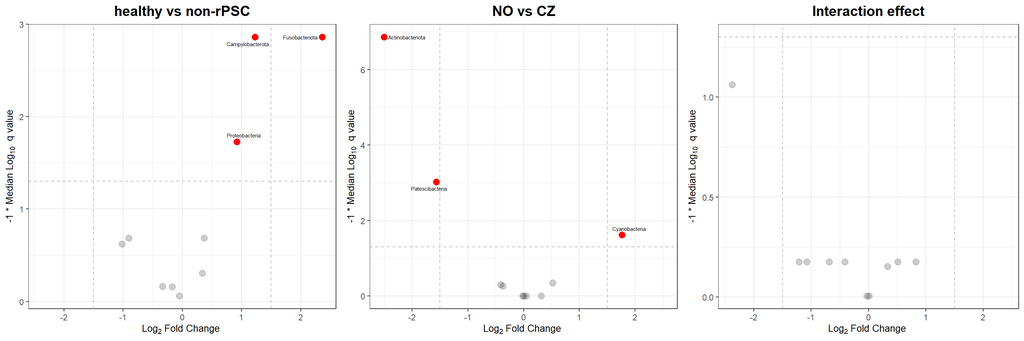

```r
volcano <- ggarrange(volcano_1,volcano_2,volcano_3, ncol=3)
volcano
```

**MaAsLin2**

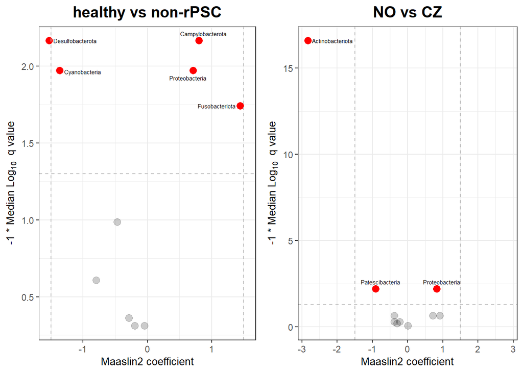

```r
volcano1 <- volcano_plot_maaslin(fit_data,filt_ileum_uni_taxa) +
            ggtitle(comparison_title)

volcano2 <- volcano_plot_maaslin(fit_data,filt_ileum_uni_taxa,variable="Country") +
            ggtitle("NO vs CZ")

volcano <- ggarrange(volcano1,volcano2, ncol=2)
volcano
```

**Group - Intersection**

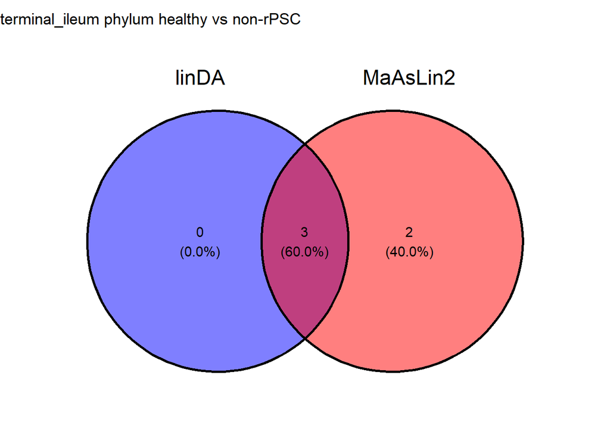

```r
intersection_results <- group_intersection(group, list_intersections, list_venns,
                                           linda.output, fit_data,
                                           raw_linda_results_phylum,
                                           segment = segment,
                                           level=level)

list_intersections <- intersection_results[[1]]
list_venns <- intersection_results[[2]]
venn <- intersection_results[[3]]

# show the results
venn
```

Interaction effect

```r
list_interaction_significant <- country_interaction(group,
                                                    linda.output,
                                                    list_intersections,
                                          filt_ileum_uni_data,
                                          filt_ileum_uni_metadata,
                                          segment=segment,
                                          level=level)

# see the result
## significant interaction effect
list_interaction_significant[[1]]
```

```r
## results for czech cohort
list_interaction_significant[[2]]
```

```
## [1] NA
```

```r
## results for norwegian cohort
list_interaction_significant[[3]]
```

```
## [1] NA
```

Removing problematic taxa

```r
list_intersections <- removing_interaction_problems(group,
                                                    list_interaction_significant,
                                                    list_intersections,
                                                    segment=segment,
                                                    level=level)
```

**Basic statistics**

```r
uni_df <-  merge(basic_univariate_statistics(linda_data,group),
                 raw_linda_results_phylum[[segment]][[group1]],
                 by="SeqID",all=TRUE)
```

```
## [1] "healthy"
## [1] "non-rPSC"
## [1] "healthy"
## [1] "non-rPSC"
```

```r
uni_df[["final_sig"]] <- uni_df$SeqID %in% list_intersections[[paste(segment,level,comparison_name)]][["SeqID"]]
uni_statistics[[segment]][[paste(level,comparison_name)]] <- uni_df

# for comparison
new_name <- paste(level,comparison_name)
addWorksheet(supplements_wb, sheetName = new_name)
writeData(supplements_wb, sheet = new_name, uni_df, rowNames=FALSE)
```

##### Visualization

Heatmap visualizing the linDA’s logFoldChange for taxa with p < 0.1.

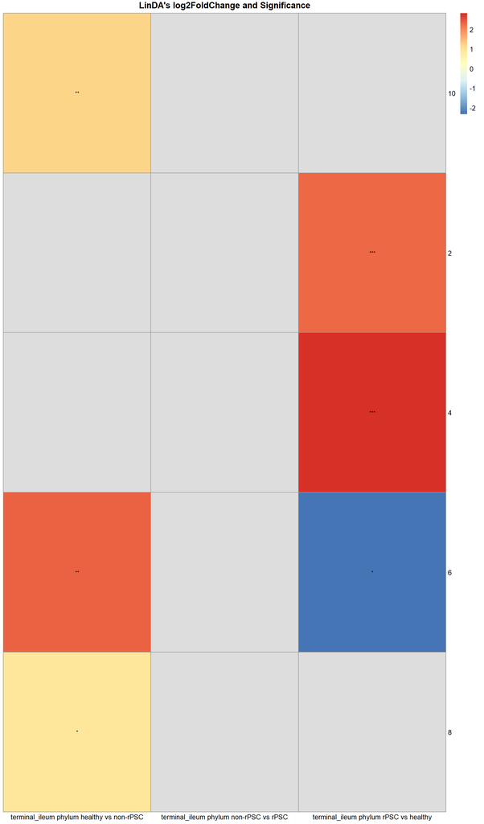

```r
list_heatmap <- list_intersections[grep(paste(segment,level),
                                  names(list_intersections),value=TRUE)]

p_heatmap_linda <- heatmap_linda(list_heatmap,ileum_taxa_tab)
p_heatmap_linda
```

Dotheatmap

```r
dotheatmap_linda <- dot_heatmap_linda(list_heatmap,
                                      uni_statistics$terminal_ileum[grepl(level,names(uni_statistics$terminal_ileum))],
                                      ileum_taxa_tab)
```

```
## min_clr -4.182065
## max_clr 4.949748
## min_log -2.332431
## max_log 2.832391
```

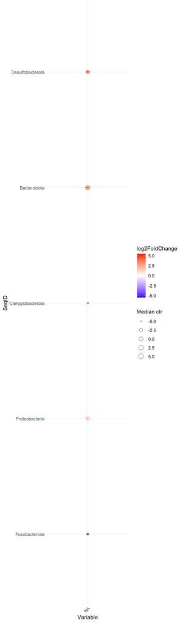

```r
dotheatmap_linda
```

##### rPSC effect

**pre_LTx vs Healthy and Post_LTx vs Healthy intersection**

```r
A <- list_intersections[[paste(segment,level,"healthy vs rPSC")]]
B <- list_intersections[[paste(segment,level,"healthy vs non-rPSC")]]
df <- A[!(A$SeqID %in% B$SeqID),]

rpsc_effect[[paste(segment,level)]] <- df

# see the results
rpsc_effect[[paste(segment,level)]]
```

#### Saving results

```r
# ALL DATA
saveWorkbook(supplements_wb,file.path(path,paste0("supplements_uni_analysis_wb_",segment,".xlsx")),overwrite = TRUE)

# PSC effect
write.xlsx(rpsc_effect,
          file.path(path,paste0("supplements_rpsc_effect_",segment,".xlsx")))

# SIGNIFICANT taxa
write.xlsx(list_intersections[grepl(segment,names(list_intersections))] %>%
            `names<-`(gsub(segment, "", names(
              list_intersections[grepl(segment,names(list_intersections))]))),
           file.path(path,paste0("supplements_significant_taxa_",segment,".xlsx")))
```

## Machine learning

```r
path = "../results/Q2/models"
```

### ElasticNet

```r
model="enet"
```

#### ASV level

```r
level="ASV"
```

##### rPSC vs non-rPSC

```r
group <- c("rPSC","non-rPSC")
comparison_name <- paste0(group[1], " vs ",group[2])
```

```r
model_name <- paste(comparison_name,level,segment)

# prepare the data
filt_ileum_uni_data <- binomial_prep(ileum_asv_tab,
                                     ileum_taxa_tab,
                                     ileum_metadata,
                                     group, usage="ml_clr")
```

```
## Removing 1127 ASV(s)
```

```
## Removing 27 ASV(s)
```

```r
# fit the model
enet_model <- glmnet_binomial(filt_ileum_uni_data,
                              sample_method = "atypboot",
                              outcome="Group",
                              N=10,
                              reuse=TRUE,
                              file=model_name,
                              Q="Q2")

# ROC curve
roc_c <- roc_curve(enet_model, group)

# save the results
models_summ <- list()
models_cm <- list()
betas <- list()
roc_cs <- list()

models_summ[[model_name]] <- enet_model$model_summary
models_cm[[model_name]] <- enet_model$conf_matrices$original
roc_cs[[model_name]] <- enet_model$kfold_rocobjs
betas[[model_name]] <- as.matrix(enet_model$betas)

# see the results
enet_model$model_summary %>% t()
```

```
##                                      [,1]
## alpha                           0.4000000
## lambda                          0.3123848
## auc                             0.5000000
## auc_czech                       0.5000000
## auc_no                          0.5000000
## auc_optimism_corrected          0.5929044
## auc_optimism_corrected_CIL      0.4774822
## auc_optimism_corrected_CIU      0.6968581
## accuracy                        0.7608696
## accuracy_czech                        NaN
## accuracy_no                     0.7500000
## accuracy_optimism_corrected     0.7325629
## accuracy_optimism_corrected_CIL 0.6374152
## accuracy_optimism_corrected_CIU 0.8114948
```

```r
enet_model$conf_matrices
```

```
## $original
##     0
## 0 105 0
## 1  33 0
##
## $czech
##    0
## 0 78 0
## 1 24 0
##
## $no
##    0
## 0 27 0
## 1  9 0
```

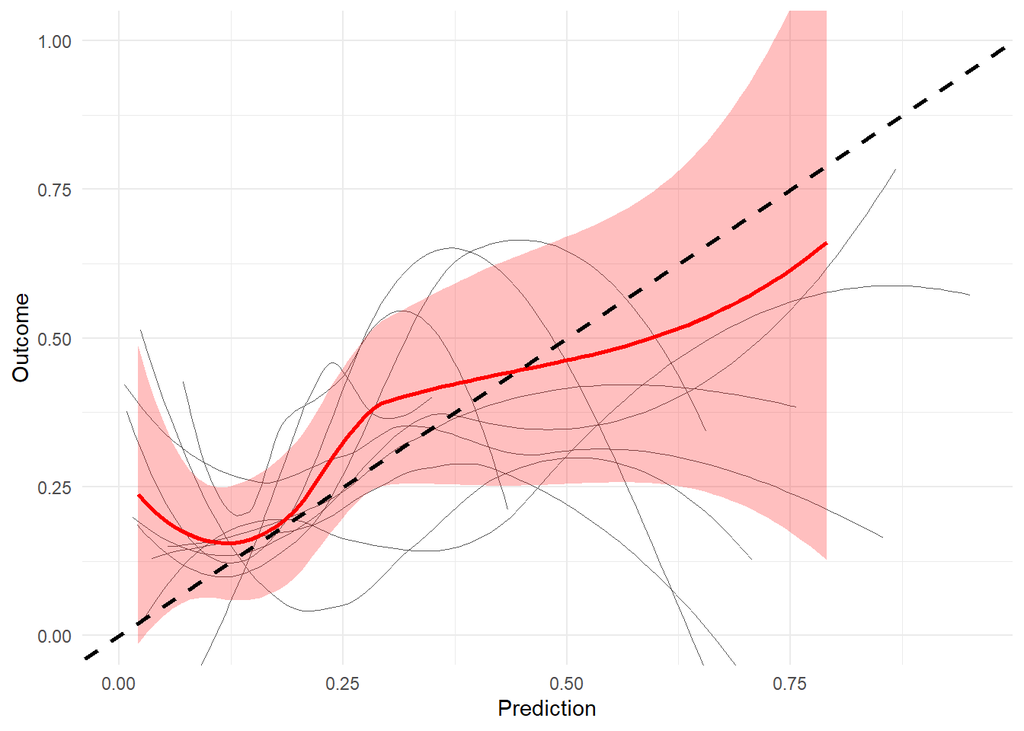

```r
enet_model$plot
```

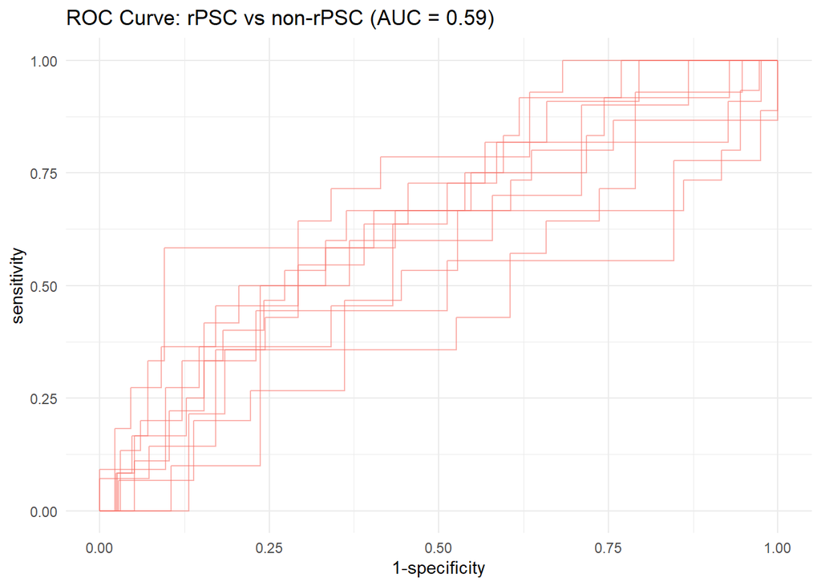

```r
roc_c
```

##### rPSC vs healthy

```r
group <- c("rPSC","healthy")
comparison_name <- paste0(group[1], " vs ",group[2])
```

```r
model_name <- paste(comparison_name,level,segment)

# prepare the data
filt_ileum_uni_data <- binomial_prep(ileum_asv_tab,
                                     ileum_taxa_tab,
                                     ileum_metadata,
                                     group,
                                     usage="ml_clr")
```

```
## Removing 1214 ASV(s)
```

```
## Removing 122 ASV(s)
```

```r
# fit the model
enet_model <- glmnet_binomial(filt_ileum_uni_data,
                              sample_method = "atypboot",
                              outcome="Group",
                              N=10,
                              reuse=TRUE,
                              file=model_name,
                              Q="Q2")

# ROC
roc_c <- roc_curve(enet_model, group)

# save the results
models_summ[[model_name]] <- enet_model$model_summary
models_cm[[model_name]] <- enet_model$conf_matrices$original
roc_cs[[model_name]] <- enet_model$kfold_rocobjs
betas[[model_name]] <- as.matrix(enet_model$betas)

# see the results
enet_model$model_summary %>% t()
```

```
##                                      [,1]
## alpha                           0.2000000
## lambda                          0.1112858
## auc                             1.0000000
## auc_czech                       1.0000000
## auc_no                          1.0000000
## auc_optimism_corrected          0.9566799
## auc_optimism_corrected_CIL      0.8962456
## auc_optimism_corrected_CIU      0.9859752
## accuracy                        1.0000000
## accuracy_czech                        NaN
## accuracy_no                     1.0000000
## accuracy_optimism_corrected     0.8766248
## accuracy_optimism_corrected_CIL 0.7993421
## accuracy_optimism_corrected_CIU 0.9369643
```

```r
enet_model$conf_matrices
```

```
## $original
##     Predicted
## True  0  1
##    0 73  0
##    1  0 33
##
## $czech
##     Predicted
## True  0  1
##    0 37  0
##    1  0 24
##
## $no
##     Predicted
## True  0  1
##    0 36  0
##    1  0  9
```

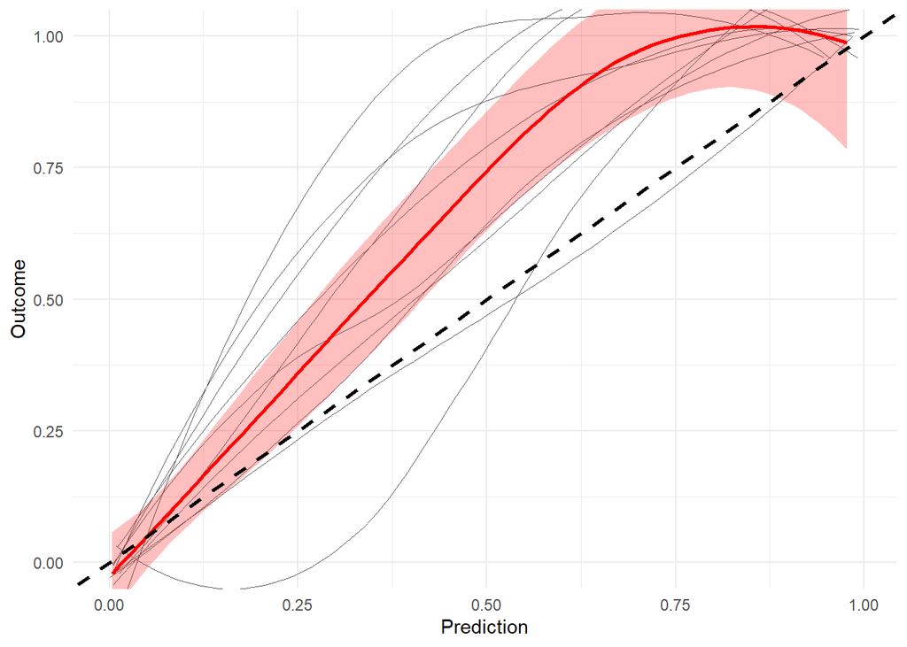

```r
enet_model$plot
```

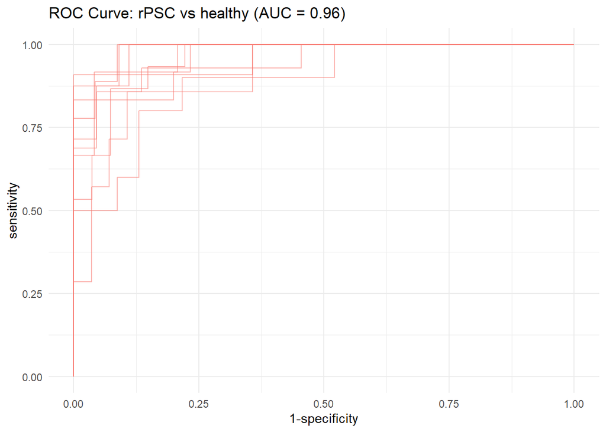

```r
roc_c
```

##### non-rPSC vs healthy

```r
group <- c("non-rPSC","healthy")
comparison_name <- paste0(group[1], " vs ",group[2])
```

```r
model_name <- paste(comparison_name,level,segment)

# prepare the data
filt_ileum_uni_data <- binomial_prep(ileum_asv_tab,
                                     ileum_taxa_tab,
                                     ileum_metadata,
                                     group,
                                     usage="ml_clr")
```

```
## Removing 392 ASV(s)
```

```
## Removing 91 ASV(s)
```

```r
# fit the model
enet_model <- glmnet_binomial(filt_ileum_uni_data,
                              sample_method = "atypboot",
                              outcome="Group",
                              N=10,
                              reuse=TRUE,
                              file=model_name,
                              Q="Q2")

# ROC
roc_c <- roc_curve(enet_model, group)

# save the results
models_summ[[model_name]] <- enet_model$model_summary
models_cm[[model_name]] <- enet_model$conf_matrices$original
roc_cs[[model_name]] <- enet_model$kfold_rocobjs
betas[[model_name]] <- as.matrix(enet_model$betas)

# see the results
enet_model$model_summary %>% t()
```

```
##                                      [,1]
## alpha                           0.2000000
## lambda                          0.0310618
## auc                             1.0000000
## auc_czech                       1.0000000
## auc_no                          1.0000000
## auc_optimism_corrected          0.9540017
## auc_optimism_corrected_CIL      0.8903546
## auc_optimism_corrected_CIU      0.9917732
## accuracy                        1.0000000
## accuracy_czech                        NaN
## accuracy_no                     1.0000000
## accuracy_optimism_corrected     0.8826334
## accuracy_optimism_corrected_CIL 0.8000000
## accuracy_optimism_corrected_CIU 0.9555696
```

```r
enet_model$conf_matrices
```

```
## $original
##     Predicted
## True   0   1
##    0  73   0
##    1   0 105
##
## $czech
##     Predicted
## True  0  1
##    0 37  0
##    1  0 78
##
## $no
##     Predicted
## True  0  1
##    0 36  0
##    1  0 27
```

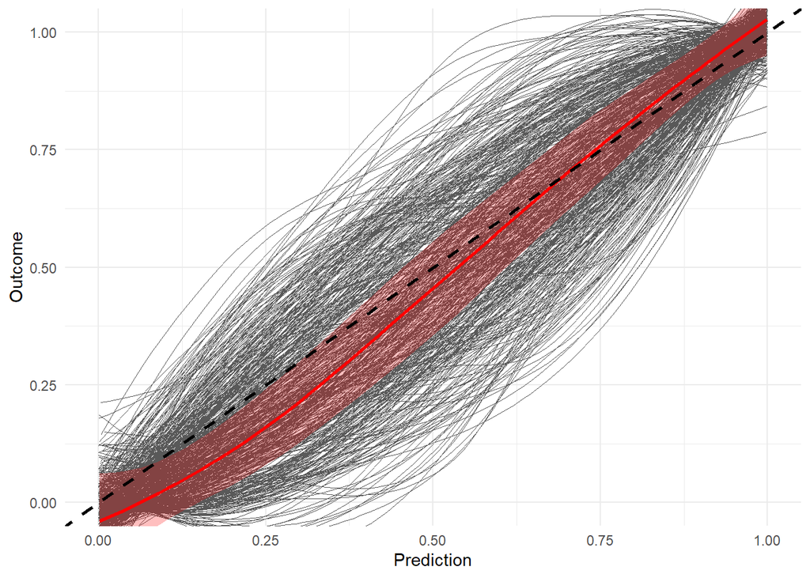

```r
enet_model$plot
```

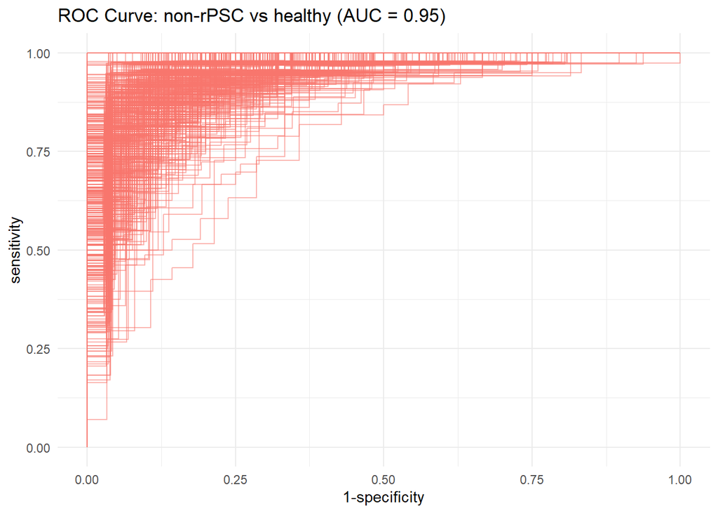

```r
roc_c
```

##### rPSC effect

```r
model_name <- paste("rPSC effect",level,segment)

# prepare the data
filt_ileum_uni_data <- binomial_prep_psc_effect(ileum_asv_tab,
                                                ileum_taxa_tab,
                                                ileum_metadata,
                                                rpsc_effect[[paste(segment,level)]],
                                                usage="ml_clr")
```

```
## Removing 1127 ASV(s)
```

```
## Removing 27 ASV(s)
```

```r
# fit the model
enet_model <- glmnet_binomial(filt_ileum_uni_data,
                              sample_method = "atypboot",
                              outcome="Group",
                              N=10,
                              reuse=TRUE,
                              file=model_name,
                              Q="Q2")

# ROC
roc_c <- roc_curve(enet_model, group)

# save the results
models_summ[[model_name]] <- enet_model$model_summary
models_cm[[model_name]] <- enet_model$conf_matrices$original
roc_cs[[model_name]] <- enet_model$kfold_rocobjs
betas[[model_name]] <- as.matrix(enet_model$betas)

# see the results
enet_model$model_summary %>% t()
```

```
##                                      [,1]
## alpha                           0.4000000
## lambda                          0.2737528
## auc                             0.6350649
## auc_czech                       0.6089744
## auc_no                          0.7037037
## auc_optimism_corrected          0.6554041
## auc_optimism_corrected_CIL      0.5197632
## auc_optimism_corrected_CIU      0.7667220
## accuracy                        0.7608696
## accuracy_czech                        NaN
## accuracy_no                     0.7500000
## accuracy_optimism_corrected     0.7583172
## accuracy_optimism_corrected_CIL 0.6754902
## accuracy_optimism_corrected_CIU 0.8096875
```

```r
enet_model$conf_matrices
```

```
## $original
##     0
## 0 105 0
## 1  33 0
##
## $czech
##    0
## 0 78 0
## 1 24 0
##
## $no
##    0
## 0 27 0
## 1  9 0
```

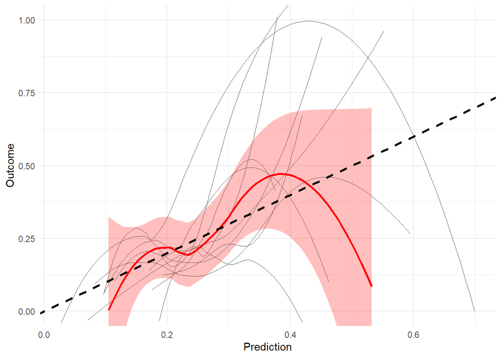

```r
enet_model$plot
```

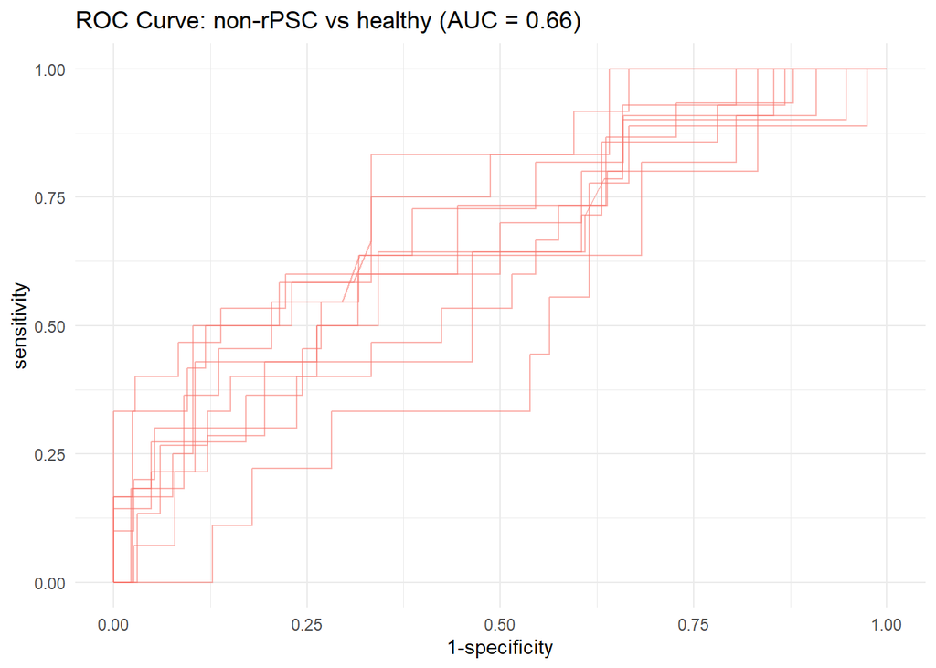

```r
roc_c
```

#### Genus level

```r
level="genus"
```

Aggregate taxa

```r
genus_data <- aggregate_taxa(ileum_asv_tab,
                             ileum_taxa_tab,
                             taxonomic_level = level)

ileum_genus_tab <- genus_data[[1]]
ileum_genus_taxa_tab <- genus_data[[2]]
```

##### rPSC vs non-rPSC

```r
group <- c("rPSC","non-rPSC")
comparison_name <- paste0(group[1], " vs ",group[2])
```

```r
model_name <- paste(comparison_name,level,segment)

# prepare the data
filt_ileum_uni_data <- binomial_prep(ileum_genus_tab,
                                     ileum_genus_taxa_tab,
                                     ileum_metadata,
                                     group,
                                     usage="ml_clr")
```

```
## Removing 55 ASV(s)
```

```
## Removing 2 ASV(s)
```

```r
# fit the model
enet_model <- glmnet_binomial(filt_ileum_uni_data,
                              sample_method = "atypboot",
                              outcome="Group",
                              N=10,
                              reuse=TRUE,
                              file=model_name,
                              Q="Q2")

# ROC
roc_c <- roc_curve(enet_model, group)

# save the results
models_summ[[model_name]] <- enet_model$model_summary
models_cm[[model_name]] <- enet_model$conf_matrices$original
roc_cs[[model_name]] <- enet_model$kfold_rocobjs
betas[[model_name]] <- as.matrix(enet_model$betas)

# see the results
enet_model$model_summary %>% t()
```

```
##                                      [,1]
## alpha                           0.4000000
## lambda                          0.3119645
## auc                             0.6432900
## auc_czech                       0.6567842
## auc_no                          0.6069959
## auc_optimism_corrected          0.5736934
## auc_optimism_corrected_CIL      0.3905857
## auc_optimism_corrected_CIU      0.7322617
## accuracy                        0.7608696
## accuracy_czech                        NaN
## accuracy_no                     0.7500000
## accuracy_optimism_corrected     0.7353858
## accuracy_optimism_corrected_CIL 0.6288683
## accuracy_optimism_corrected_CIU 0.8277572
```

```r
enet_model$conf_matrices
```

```
## $original
##     0
## 0 105 0
## 1  33 0
##
## $czech
##    0
## 0 78 0
## 1 24 0
##
## $no
##    0
## 0 27 0
## 1  9 0
```

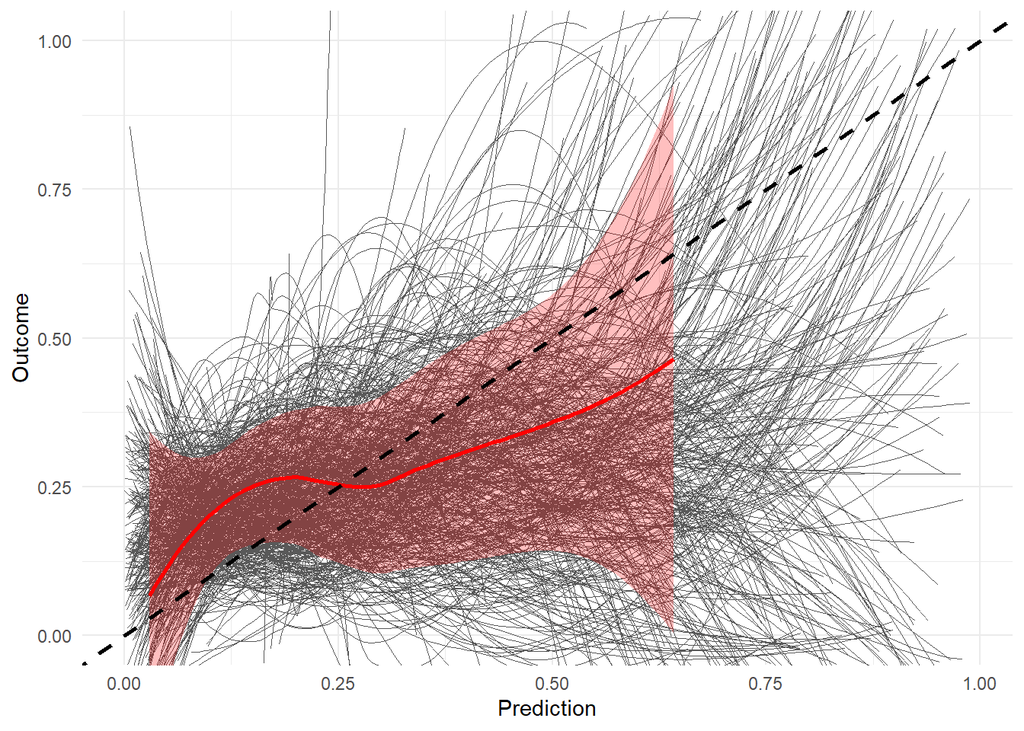

```r
enet_model$plot
```

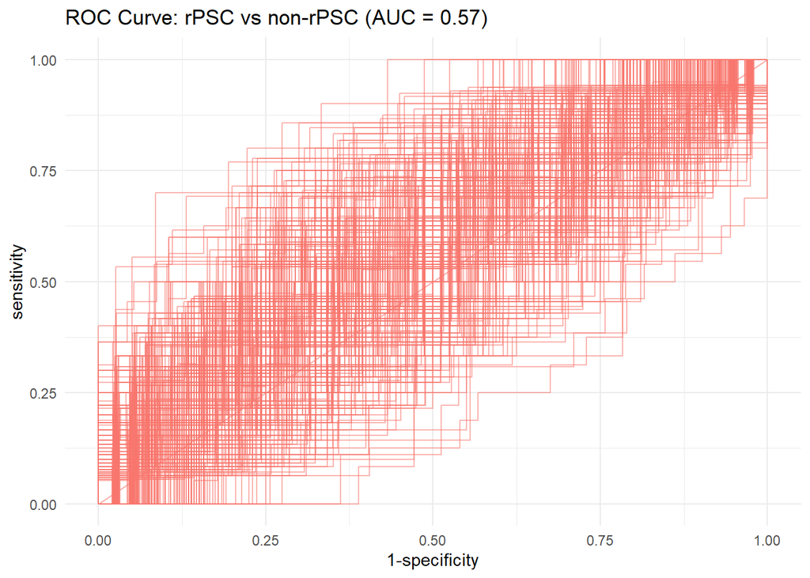

```r
roc_c
```

##### rPSC vs healthy

```r
group <- c("rPSC","healthy")
comparison_name <- paste0(group[1], " vs ",group[2])
```

```r
model_name <- paste(comparison_name,level,segment)

# prepare the data
filt_ileum_uni_data <- binomial_prep(ileum_genus_tab,
                                     ileum_genus_taxa_tab,
                                     ileum_metadata,
                                     group,
                                     usage="ml_clr")
```

```
## Removing 67 ASV(s)
```

```
## Removing 4 ASV(s)
```

```r
# fit the model
enet_model <- glmnet_binomial(filt_ileum_uni_data,
                              sample_method = "atypboot",
                              outcome="Group", N=10,
                              reuse=TRUE,
                              file=model_name,
                              Q="Q2")

# ROC
roc_c <- roc_curve(enet_model, group)

# save the results
models_summ[[model_name]] <- enet_model$model_summary
models_cm[[model_name]] <- enet_model$conf_matrices$original
roc_cs[[model_name]] <- enet_model$kfold_rocobjs
betas[[model_name]] <- as.matrix(enet_model$betas)

# see the results
enet_model$model_summary %>% t()
```

```
##                                      [,1]
## alpha                           0.2000000
## lambda                          0.1466508
## auc                             1.0000000
## auc_czech                       1.0000000
## auc_no                          1.0000000
## auc_optimism_corrected          0.9173741
## auc_optimism_corrected_CIL      0.8053840
## auc_optimism_corrected_CIU      0.9910210
## accuracy                        0.9811321
## accuracy_czech                        NaN
## accuracy_no                     0.9777778
## accuracy_optimism_corrected     0.8536658
## accuracy_optimism_corrected_CIL 0.7306691
## accuracy_optimism_corrected_CIU 0.9500000
```

```r
enet_model$conf_matrices
```

```
## $original
##     Predicted
## True  0  1
##    0 73  0
##    1  2 31
##
## $czech
##     Predicted
## True  0  1
##    0 37  0
##    1  1 23
##
## $no
##     Predicted
## True  0  1
##    0 36  0
##    1  1  8
```

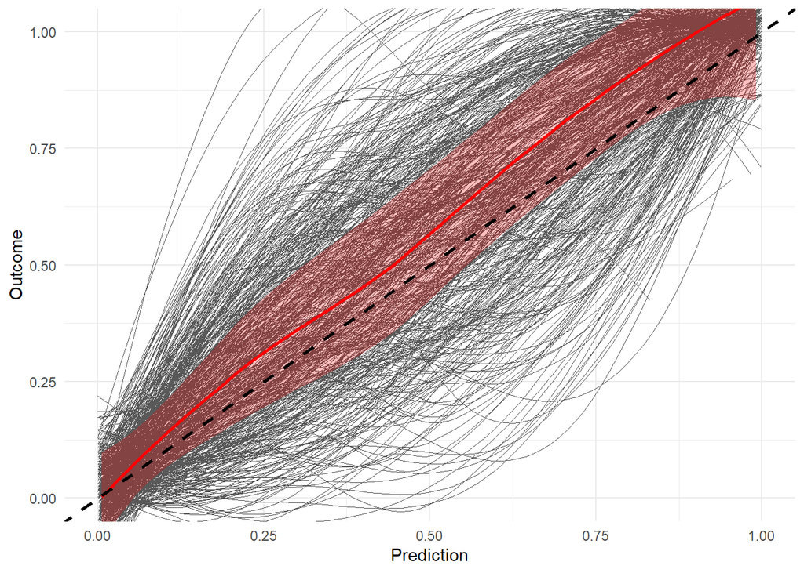

```r
enet_model$plot
```

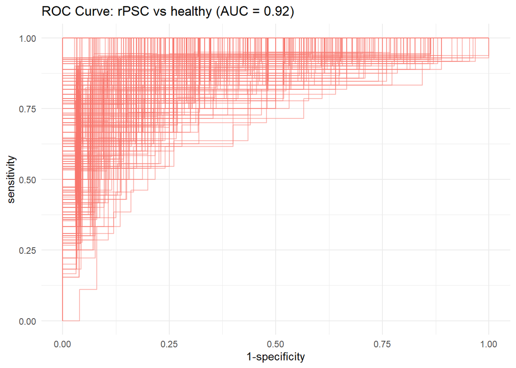

```r
roc_c
```

##### non-rPSC vs healthy

```r
group <- c("non-rPSC","healthy")
comparison_name <- paste0(group[1], " vs ",group[2])
```

```r
model_name <- paste(comparison_name,level,segment)

# prepare the data
filt_ileum_uni_data <- binomial_prep(ileum_genus_tab,
                                     ileum_genus_taxa_tab,
                                     ileum_metadata,group,
                                     usage="ml_clr")
```

```
## Removing 24 ASV(s)
```

```
## Removing 2 ASV(s)
```

```r
# fit the model
enet_model <- glmnet_binomial(filt_ileum_uni_data,
                              sample_method = "atypboot",
                              outcome="Group",
                              N=10,
                              reuse=TRUE,
                              file=model_name,
                              Q="Q2")

# ROC
roc_c <- roc_curve(enet_model, group)

# save the results
models_summ[[model_name]] <- enet_model$model_summary
models_cm[[model_name]] <- enet_model$conf_matrices$original
roc_cs[[model_name]] <- enet_model$kfold_rocobjs
betas[[model_name]] <- as.matrix(enet_model$betas)

# see the results
enet_model$model_summary %>% t()
```

```
##                                      [,1]
## alpha                           0.2000000
## lambda                          0.0419208
## auc                             1.0000000
## auc_czech                       1.0000000
## auc_no                          1.0000000
## auc_optimism_corrected          0.9607678
## auc_optimism_corrected_CIL      0.9109397
## auc_optimism_corrected_CIU      0.9923372
## accuracy                        1.0000000
## accuracy_czech                        NaN
## accuracy_no                     1.0000000
## accuracy_optimism_corrected     0.8893031
## accuracy_optimism_corrected_CIL 0.8000000
## accuracy_optimism_corrected_CIU 0.9535036
```

```r
enet_model$conf_matrices
```

```
## $original
##     Predicted
## True   0   1
##    0  73   0
##    1   0 105
##
## $czech
##     Predicted
## True  0  1
##    0 37  0
##    1  0 78
##
## $no
##     Predicted
## True  0  1
##    0 36  0
##    1  0 27
```

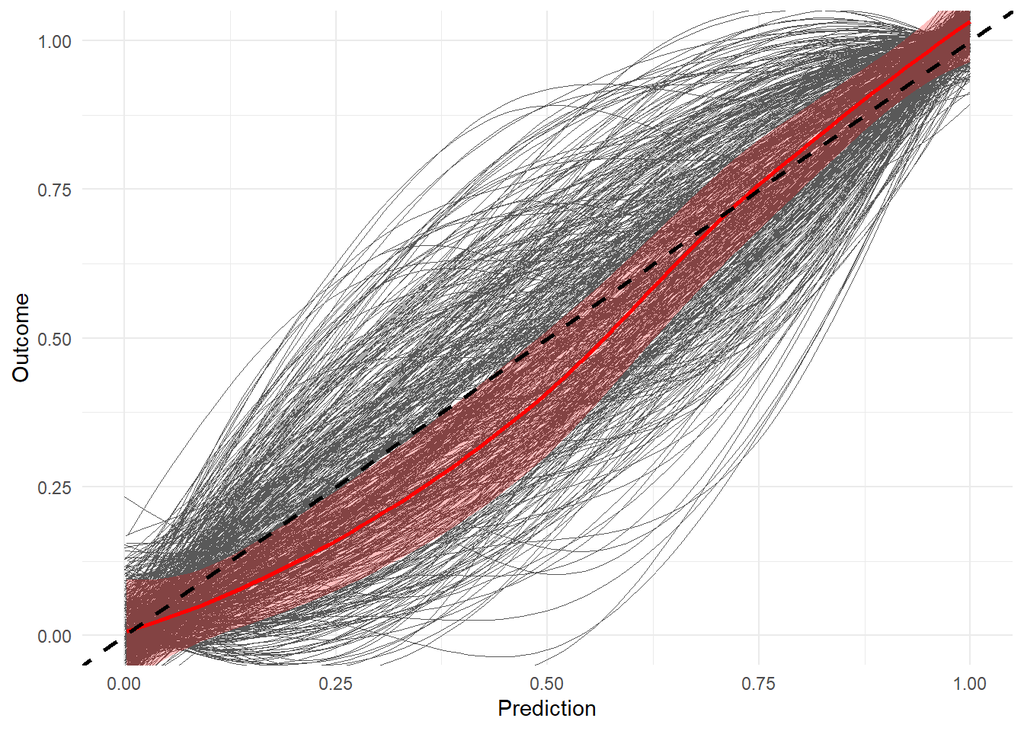

```r
enet_model$plot
```

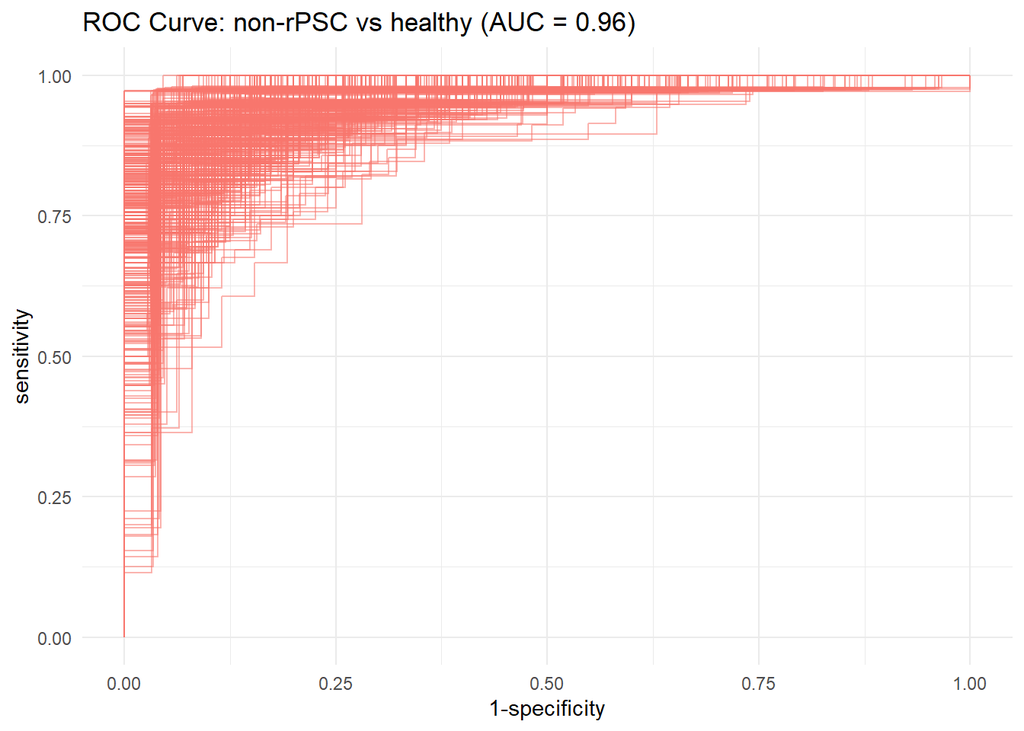

```r
roc_c
```

##### rPSC effect

```r
model_name <- paste("rPSC effect",level,segment)

# prepare the data
filt_ileum_uni_data <- binomial_prep_psc_effect(ileum_genus_tab,
                                                ileum_genus_taxa_tab,
                                                ileum_metadata,
                                                rpsc_effect[[paste(segment,level)]],
                                                usage="ml_clr")
```

```
## Removing 55 ASV(s)
```

```
## Removing 2 ASV(s)
```

```r
# fit the model
enet_model <- glmnet_binomial(filt_ileum_uni_data,
                              sample_method = "atypboot",
                              outcome="Group",
                              N=500,
                              reuse=TRUE,
                              file=model_name,
                              Q="Q2")

# ROC
roc_c <- roc_curve(enet_model, group)

# save the results
models_summ[[model_name]] <- enet_model$model_summary
models_cm[[model_name]] <- enet_model$conf_matrices$original
roc_cs[[model_name]] <- enet_model$kfold_rocobjs
betas[[model_name]] <- as.matrix(enet_model$betas)

# see the results
enet_model$model_summary %>% t()
```

```
##                                      [,1]
## alpha                           0.4000000
## lambda                          0.3616408
## auc                             0.5000000
## auc_czech                       0.5000000
## auc_no                          0.5000000
## auc_optimism_corrected          0.6226149
## auc_optimism_corrected_CIL      0.4757437
## auc_optimism_corrected_CIU      0.7862525
## accuracy                        0.7608696
## accuracy_czech                        NaN
## accuracy_no                     0.7500000
## accuracy_optimism_corrected     0.7663989
## accuracy_optimism_corrected_CIL 0.6730769
## accuracy_optimism_corrected_CIU 0.8571429
```

```r
enet_model$conf_matrices
```

```
## $original
##     0
## 0 105 0
## 1  33 0
##
## $czech
##    0
## 0 78 0
## 1 24 0
##
## $no
##    0
## 0 27 0
## 1  9 0
```

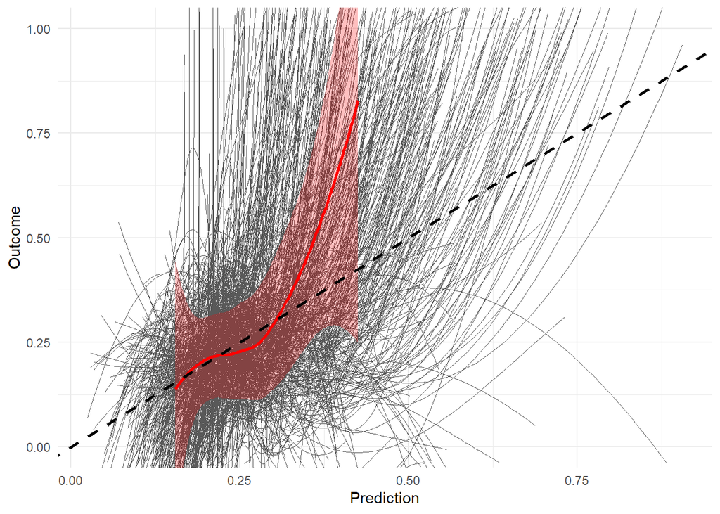

```r
enet_model$plot
```

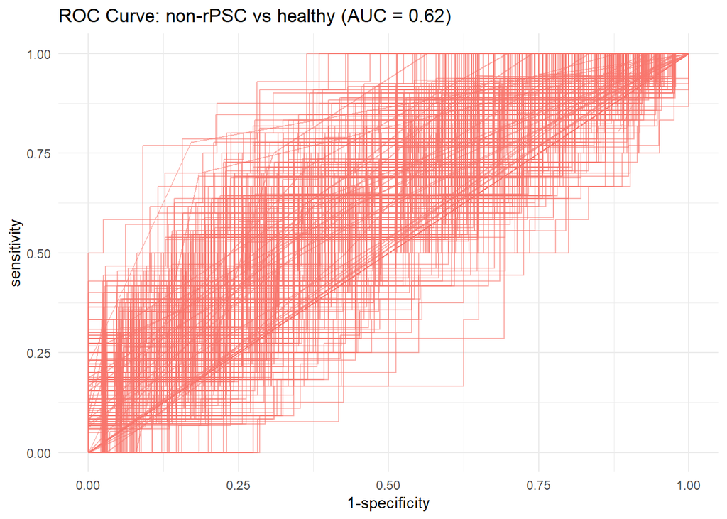

```r
roc_c
```

#### Saving results

```r
models_summ_df_ileum <- do.call(rbind,
  models_summ[grep(segment,names(models_summ),value = TRUE)])

write.csv(models_summ_df_ileum,file.path(path,paste0("elastic_net_",segment,".csv")))
```

### Supplementary models

```r
supplements_models <- list()
```

#### CLR-transformed data

##### kNN

```r
model="knn"
```

###### ASV level

```r
level="ASV"
```

*rPSC vs non-rPSC*

```r
group <- c("rPSC","non-rPSC")
comparison_name <- paste0(group[1], " vs ",group[2])
```

```r
model_name <- paste(comparison_name,level,segment)

# prepare the data
filt_ileum_uni_data <- binomial_prep(ileum_asv_tab,
                                     ileum_taxa_tab,
                                     ileum_metadata,
                                     group, usage="ml_clr")
```

```
## Removing 1127 ASV(s)
```

```
## Removing 27 ASV(s)
```

```r
# fit the model
knn_model <- knn_binomial(filt_ileum_uni_data,
                              sample_method = "atypboot",
                              outcome="Group",
                              N=10,
                              reuse=TRUE,
                              file=model_name,
                              Q="Q2")

# ROC curve
roc_c <- roc_curve(knn_model, group)

# save the results
supplements_models[["models_summ"]][["knn_model"]][[model_name]] <- knn_model$model_summary
supplements_models[["roc_cs"]][["knn_model"]][[model_name]] <- knn_model$kfold_rocobjs

# see the results
knn_model$model_summary %>% t()
```

```
##                                       [,1]
## k                               30.0000000
## auc                              0.7075036
## auc_optimism_corrected           0.5690333
## auc_optimism_corrected_CIL       0.3766176
## auc_optimism_corrected_CIU       0.6993946
## accuracy                         0.7608696
## accuracy_optimism_corrected      0.7565703
## accuracy_optimism_corrected_CIL  0.6916360
## accuracy_optimism_corrected_CIU  0.7916667
```

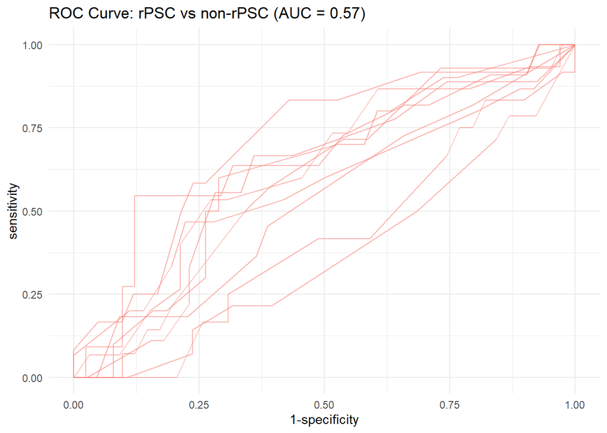

```r
roc_c
```

**rPSC vs healthy**

```r
group <- c("rPSC","healthy")
comparison_name <- paste0(group[1], " vs ",group[2])
```

```r
model_name <- paste(comparison_name,level,segment)


# prepare the data
filt_ileum_uni_data <- binomial_prep(ileum_asv_tab,
                                     ileum_taxa_tab,
                                     ileum_metadata,
                                     group, usage="ml_clr")
```

```
## Removing 1214 ASV(s)
```

```
## Removing 122 ASV(s)
```

```r
# fit the model
knn_model <- knn_binomial(filt_ileum_uni_data,
                              sample_method = "atypboot",
                              outcome="Group",
                              N=10,
                              reuse=TRUE,
                              file=model_name,
                              Q="Q2")

# ROC curve
roc_c <- roc_curve(knn_model, group)

# save the results
supplements_models[["models_summ"]][["knn_model"]][[model_name]] <- knn_model$model_summary
supplements_models[["roc_cs"]][["knn_model"]][[model_name]] <- knn_model$kfold_rocobjs


# see the results
knn_model$model_summary %>% t()
```

```
##                                       [,1]
## k                               11.0000000
## auc                              0.9618099
## auc_optimism_corrected           0.8903596
## auc_optimism_corrected_CIL       0.8195214
## auc_optimism_corrected_CIU       0.9472403
## accuracy                         0.8301887
## accuracy_optimism_corrected      0.7865538
## accuracy_optimism_corrected_CIL  0.6431652
## accuracy_optimism_corrected_CIU  0.8817460
```

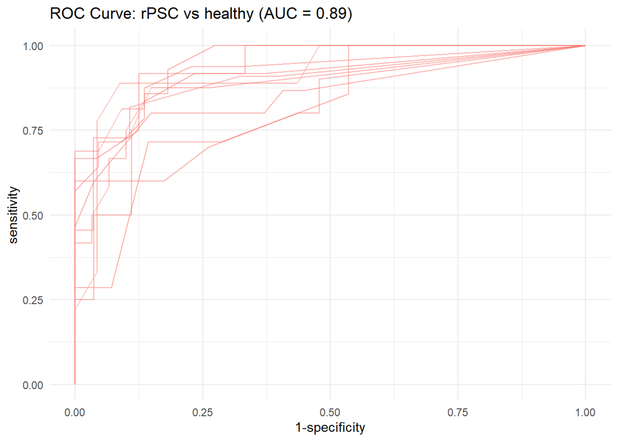

```r
roc_c
```

**non-rPSC vs healthy**

```r
group <- c("non-rPSC","healthy")
comparison_name <- paste0(group[1], " vs ",group[2])
```

```r
model_name <- paste(comparison_name,level,segment)

# prepare the data
filt_ileum_uni_data <- binomial_prep(ileum_asv_tab,
                                     ileum_taxa_tab,
                                     ileum_metadata,
                                     group, usage="ml_clr")
```

```
## Removing 392 ASV(s)
```

```
## Removing 91 ASV(s)
```

```r
# fit the model
knn_model <- knn_binomial(filt_ileum_uni_data,
                              sample_method = "atypboot",
                              outcome="Group",
                              N=10,
                              reuse=TRUE,
                              file=model_name,
                              Q="Q2")

# ROC curve
roc_c <- roc_curve(knn_model, group)

# save the results
# save the results
supplements_models[["models_summ"]][["knn_model"]][[model_name]] <- knn_model$model_summary
supplements_models[["roc_cs"]][["knn_model"]][[model_name]] <- knn_model$kfold_rocobjs

# see the results
knn_model$model_summary %>% t()
```

```
##                                       [,1]
## k                               30.0000000
## auc                              0.9123940
## auc_optimism_corrected           0.8660582
## auc_optimism_corrected_CIL       0.7600969
## auc_optimism_corrected_CIU       0.9510752
## accuracy                         0.8426966
## accuracy_optimism_corrected      0.7898668
## accuracy_optimism_corrected_CIL  0.6865625
## accuracy_optimism_corrected_CIU  0.8953109
```

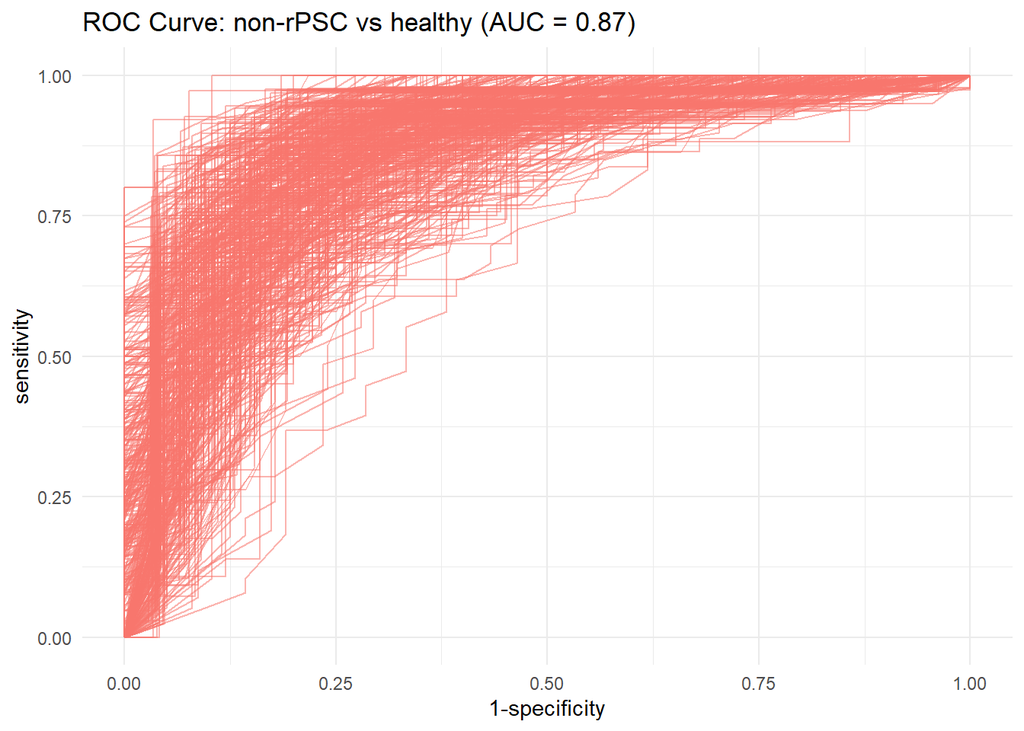

```r
roc_c
```

**rPSC effect**

```r
model_name <- paste("rPSC effect",level,segment)

# prepare the data
filt_ileum_uni_data <- binomial_prep_psc_effect(ileum_asv_tab,
                                                ileum_taxa_tab,
                                                ileum_metadata,
                                                rpsc_effect[[paste(segment,level)]],
                                                usage="ml_clr")
```

```
## Removing 1127 ASV(s)
```

```
## Removing 27 ASV(s)
```

```r
# fit the model
knn_model <- knn_binomial(filt_ileum_uni_data,
                              sample_method = "atypboot",
                              outcome="Group",
                              N=10,
                              reuse=TRUE,
                              file=model_name,
                              Q="Q2")

# ROC curve
roc_c <- roc_curve(knn_model, group)

# save the results
# save the results
supplements_models[["models_summ"]][["knn_model"]][[model_name]] <- knn_model$model_summary
supplements_models[["roc_cs"]][["knn_model"]][[model_name]] <- knn_model$kfold_rocobjs

# see the results
knn_model$model_summary %>% t()
```

```
##                                       [,1]
## k                               15.0000000
## auc                              0.7424242
## auc_optimism_corrected           0.6372846
## auc_optimism_corrected_CIL       0.5144382
## auc_optimism_corrected_CIU       0.7584529
## accuracy                         0.7753623
## accuracy_optimism_corrected      0.7609173
## accuracy_optimism_corrected_CIL  0.6960478
## accuracy_optimism_corrected_CIU  0.8125000
```

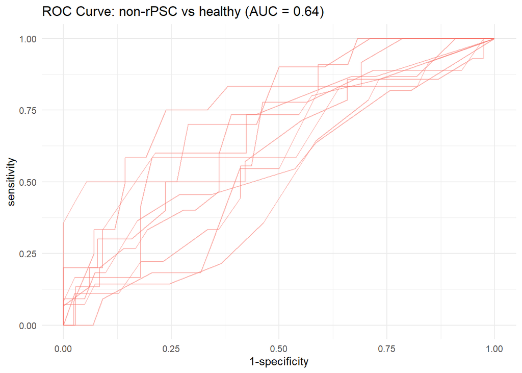

```r
roc_c
```

###### Genus level

```r
level="genus"
```

Aggregate taxa

```r
genus_data <- aggregate_taxa(ileum_asv_tab,
                             ileum_taxa_tab,
                             taxonomic_level = level)

ileum_genus_tab <- genus_data[[1]]
ileum_genus_taxa_tab <- genus_data[[2]]
```

**rPSC vs non-rPSC**

```r
group <- c("rPSC","non-rPSC")
comparison_name <- paste0(group[1], " vs ",group[2])
```

```r
model_name <- paste(comparison_name,level,segment)

# prepare the data
filt_ileum_uni_data <- binomial_prep(ileum_genus_tab,
                                     ileum_genus_taxa_tab,
                                     ileum_metadata,
                                     group,
                                     usage="ml_clr")
```

```
## Removing 55 ASV(s)
```

```
## Removing 2 ASV(s)
```

```r
# fit the model
knn_model <- knn_binomial(filt_ileum_uni_data,
                              sample_method = "atypboot",
                              outcome="Group",
                              N=10,
                              reuse=TRUE,
                              file=model_name,
                              Q="Q2")

# ROC curve
roc_c <- roc_curve(knn_model, group)

# save the results
supplements_models[["models_summ"]][["knn_model"]][[model_name]] <- knn_model$model_summary
supplements_models[["roc_cs"]][["knn_model"]][[model_name]] <- knn_model$kfold_rocobjs


# see the results
knn_model$model_summary %>% t()
```

```
##                                       [,1]
## k                               30.0000000
## auc                              0.6545455
## auc_optimism_corrected           0.5178066
## auc_optimism_corrected_CIL       0.3207460
## auc_optimism_corrected_CIU       0.6850148
## accuracy                         0.7608696
## accuracy_optimism_corrected      0.7569849
## accuracy_optimism_corrected_CIL  0.6597766
## accuracy_optimism_corrected_CIU  0.8489674
```

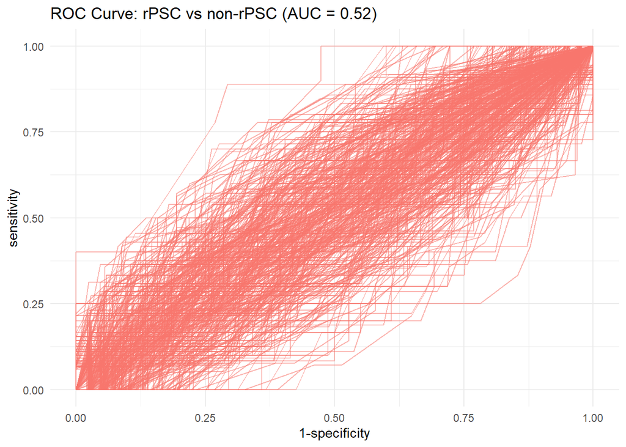

```r
roc_c
```

**rPSC vs healthy**

```r
group <- c("rPSC","healthy")
comparison_name <- paste0(group[1], " vs ",group[2])
```

```r
model_name <- paste(comparison_name,level,segment)

# prepare the data
filt_ileum_uni_data <- binomial_prep(ileum_genus_tab,
                                     ileum_genus_taxa_tab,
                                     ileum_metadata,
                                     group,
                                     usage="ml_clr")
```

```
## Removing 67 ASV(s)
```

```
## Removing 4 ASV(s)
```

```r
# fit the model
knn_model <- knn_binomial(filt_ileum_uni_data,
                              sample_method = "atypboot",
                              outcome="Group",
                              N=10,
                              reuse=TRUE,
                              file=model_name,
                              Q="Q2")

# ROC curve
roc_c <- roc_curve(knn_model, group)

# save the results
supplements_models[["models_summ"]][["knn_model"]][[model_name]] <- knn_model$model_summary
supplements_models[["roc_cs"]][["knn_model"]][[model_name]] <- knn_model$kfold_rocobjs


# see the results
knn_model$model_summary %>% t()
```

```
##                                       [,1]
## k                               11.0000000
## auc                              0.9798672
## auc_optimism_corrected           0.8904985
## auc_optimism_corrected_CIL       0.7519535
## auc_optimism_corrected_CIU       0.9869862
## accuracy                         0.7830189
## accuracy_optimism_corrected      0.7607936
## accuracy_optimism_corrected_CIL  0.6190923
## accuracy_optimism_corrected_CIU  0.8750782
```

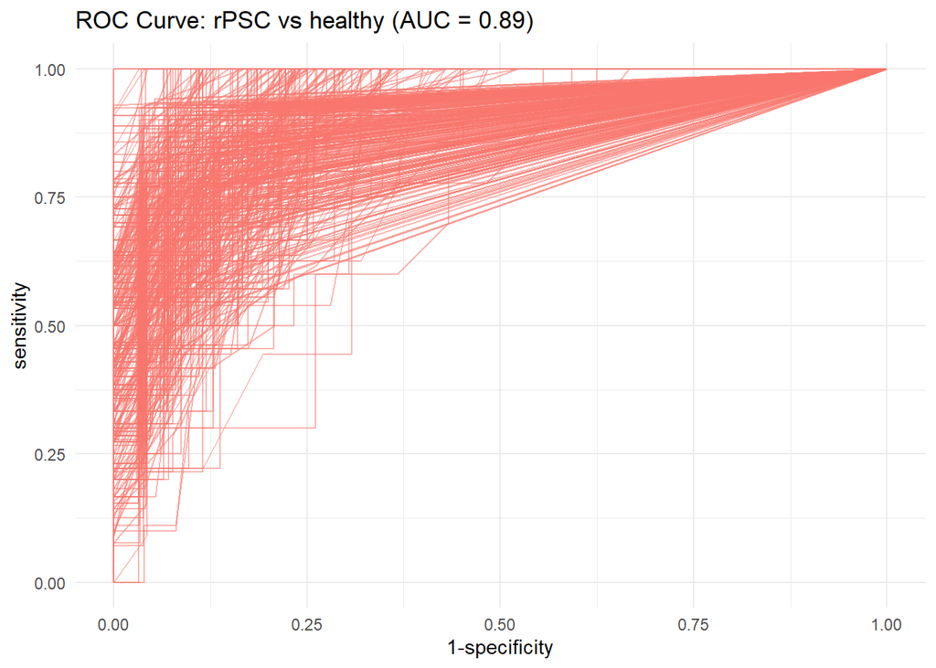

```r
roc_c
```

**non-rPSC vs healthy**

```r
group <- c("non-rPSC","healthy")
comparison_name <- paste0(group[1], " vs ",group[2])
```

```r
model_name <- paste(comparison_name,level,segment)

# prepare the data
filt_ileum_uni_data <- binomial_prep(ileum_genus_tab,
                                     ileum_genus_taxa_tab,
                                     ileum_metadata,
                                     group,
                                     usage="ml_clr")
```

```
## Removing 24 ASV(s)
```

```
## Removing 2 ASV(s)
```

```r
# fit the model
knn_model <- knn_binomial(filt_ileum_uni_data,
                              sample_method = "atypboot",
                              outcome="Group",
                              N=10,
                              reuse=TRUE,
                              file=model_name,
                              Q="Q2")

# ROC curve
roc_c <- roc_curve(knn_model, group)

# save the results
supplements_models[["models_summ"]][["knn_model"]][[model_name]] <- knn_model$model_summary
supplements_models[["roc_cs"]][["knn_model"]][[model_name]] <- knn_model$kfold_rocobjs


# see the results
knn_model$model_summary %>% t()
```

```
##                                       [,1]
## k                               11.0000000
## auc                              0.9592955
## auc_optimism_corrected           0.9106348
## auc_optimism_corrected_CIL       0.8344352
## auc_optimism_corrected_CIU       0.9684145
## accuracy                         0.8483146
## accuracy_optimism_corrected      0.7688804
## accuracy_optimism_corrected_CIL  0.6340873
## accuracy_optimism_corrected_CIU  0.8733036
```

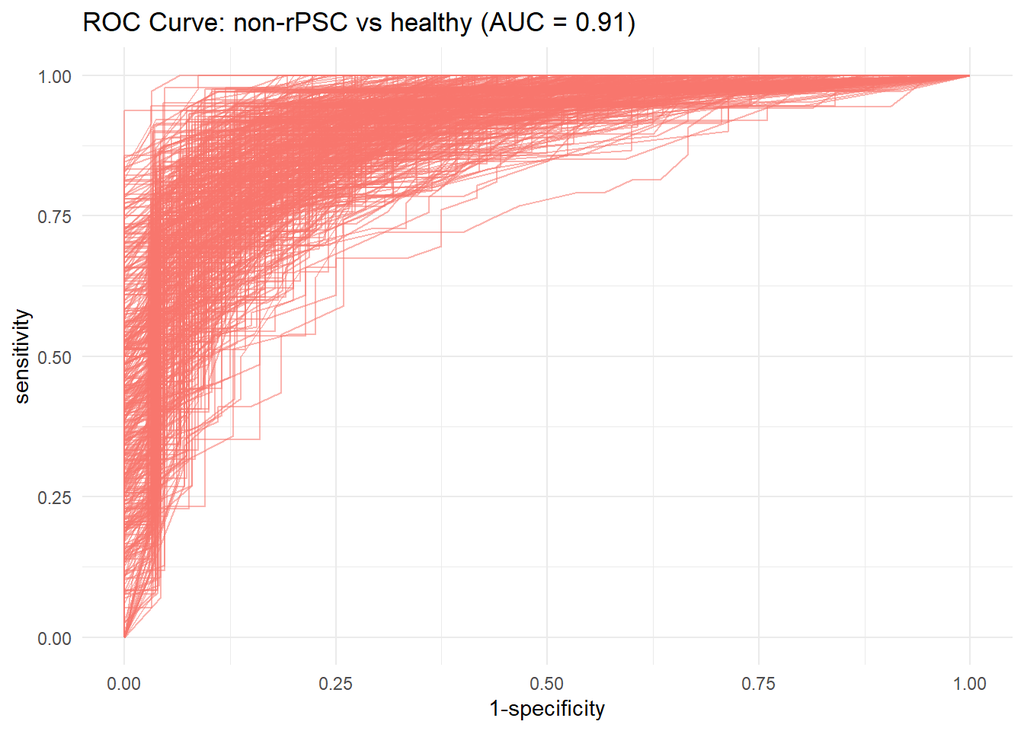

```r
roc_c
```

**rPSC effect**

```r
model_name <- paste("rPSC effect",level,segment)

# prepare the data
filt_ileum_uni_data <- binomial_prep_psc_effect(ileum_genus_tab,
                                                ileum_genus_taxa_tab,
                                                ileum_metadata,
                                                rpsc_effect[[paste(segment,level)]],
                                                usage="ml_clr")
```

```
## Removing 55 ASV(s)
```

```
## Removing 2 ASV(s)
```

```r
# fit the model
knn_model <- knn_binomial(filt_ileum_uni_data,
                              sample_method = "atypboot",
                              outcome="Group",
                              N=500,
                              reuse=TRUE,
                              file=model_name,
                              Q="Q2")

# ROC curve
roc_c <- roc_curve(knn_model, group)

# save the results
# save the results
supplements_models[["models_summ"]][["knn_model"]][[model_name]] <- knn_model$model_summary
supplements_models[["roc_cs"]][["knn_model"]][[model_name]] <- knn_model$kfold_rocobjs

# see the results
knn_model$model_summary %>% t()
```

```
##                                       [,1]
## k                               30.0000000
## auc                              0.6939394
## auc_optimism_corrected           0.5477962
## auc_optimism_corrected_CIL       0.3685868
## auc_optimism_corrected_CIU       0.7246511
## accuracy                         0.7608696
## accuracy_optimism_corrected      0.7431878
## accuracy_optimism_corrected_CIL  0.6391064
## accuracy_optimism_corrected_CIU  0.8284268
```

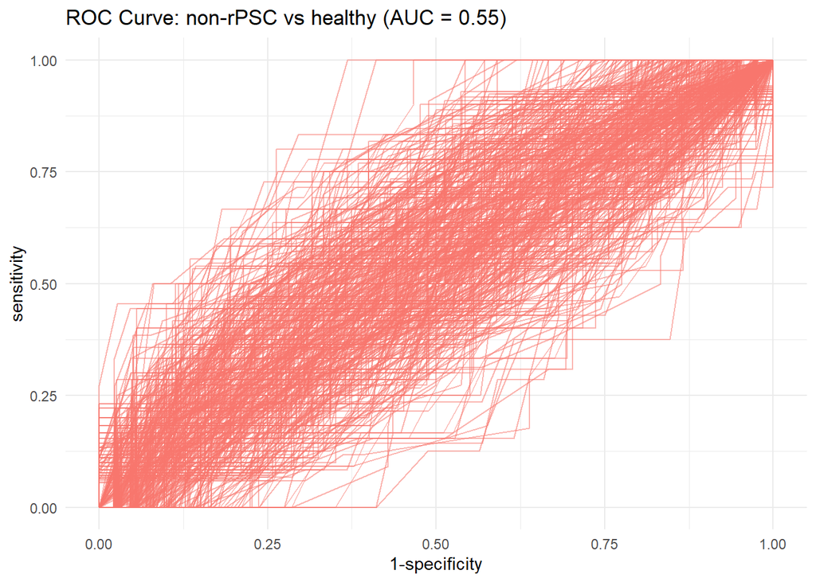

```r
roc_c
```

##### Random Forest

```r
model="rf"
```

###### ASV level

```r
level="ASV"
```

*rPSC vs non-rPSC*

```r
group <- c("rPSC","non-rPSC")
comparison_name <- paste0(group[1], " vs ",group[2])
```

```r
model_name <- paste(comparison_name,level,segment)

# prepare the data
filt_ileum_uni_data <- binomial_prep(ileum_asv_tab,
                                     ileum_taxa_tab,
                                     ileum_metadata,
                                     group, usage="ml_clr")
```

```
## Removing 1127 ASV(s)
```

```
## Removing 27 ASV(s)
```

```r
# fit the model
rf_model <- rf_binomial(filt_ileum_uni_data,
                              sample_method = "atypboot",
                              outcome="Group",
                              N=10,
                              reuse=TRUE,
                              file=model_name,
                              Q="Q2")

# ROC curve
roc_c <- roc_curve(rf_model, group)

# save the results
supplements_models[["models_summ"]][["rf_model"]][[model_name]] <- rf_model$model_summary
supplements_models[["roc_cs"]][["rf_model"]][[model_name]] <- rf_model$kfold_rocobjs

# see the results
rf_model$model_summary %>% t()
```

```
##                                 [,1]
## mtry                            "121"
## splitrule                       "gini"
## min.node.size                   "5"
## auc                             "1"
## auc_optimism_corrected          "0.5849764"
## auc_optimism_corrected_CIL      "0.4977469"
## auc_optimism_corrected_CIU      "0.6674945"
## accuracy                        "1"
## accuracy_optimism_corrected     "0.758507"
## accuracy_optimism_corrected_CIL "0.6912377"
## accuracy_optimism_corrected_CIU "0.8275641"
```

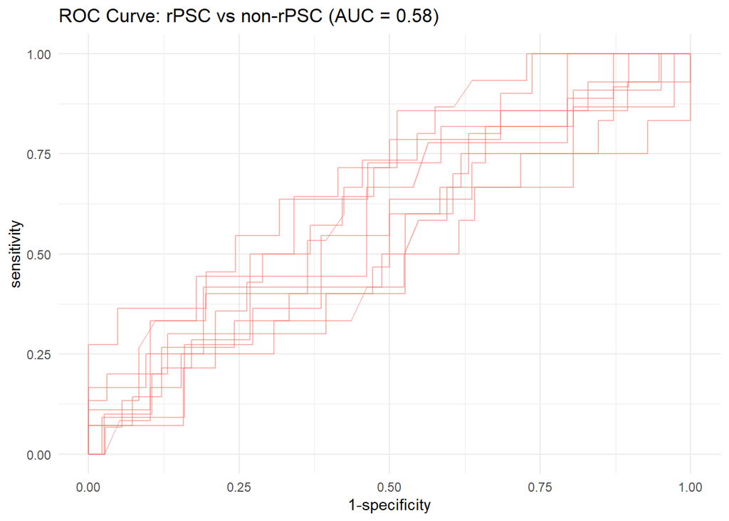

```r
roc_c
```

**rPSC vs healthy**

```r
group <- c("rPSC","healthy")
comparison_name <- paste0(group[1], " vs ",group[2])
```

```r
model_name <- paste(comparison_name,level,segment)

# prepare the data
filt_ileum_uni_data <- binomial_prep(ileum_asv_tab,
                                     ileum_taxa_tab,
                                     ileum_metadata,
                                     group, usage="ml_clr")
```

```
## Removing 1214 ASV(s)
```

```
## Removing 122 ASV(s)
```

```r
# fit the model
rf_model <- rf_binomial(filt_ileum_uni_data,
                              sample_method = "atypboot",
                              outcome="Group",
                              N=10,
                              reuse=TRUE,
                              file=model_name,
                              Q="Q2")

# ROC curve
roc_c <- roc_curve(rf_model, group)

# save the results
supplements_models[["models_summ"]][["rf_model"]][[model_name]] <- rf_model$model_summary
supplements_models[["roc_cs"]][["rf_model"]][[model_name]] <- rf_model$kfold_rocobjs

# see the results
rf_model$model_summary %>% t()
```

```
##                                 [,1]
## mtry                            "325"
## splitrule                       "gini"
## min.node.size                   "5"
## auc                             "1"
## auc_optimism_corrected          "0.9211468"
## auc_optimism_corrected_CIL      "0.7937378"
## auc_optimism_corrected_CIU      "0.972576"
## accuracy                        "1"
## accuracy_optimism_corrected     "0.8046381"
## accuracy_optimism_corrected_CIL "0.6938995"
## accuracy_optimism_corrected_CIU "0.8602183"
```

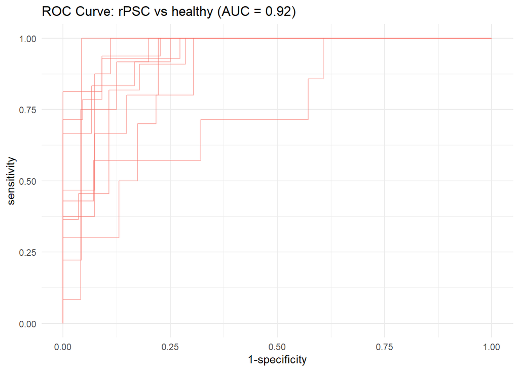

```r
roc_c
```

**non-rPSC vs healthy**

```r
group <- c("non-rPSC","healthy")
comparison_name <- paste0(group[1], " vs ",group[2])
```

```r
model_name <- paste(comparison_name,level,segment)

# prepare the data
filt_ileum_uni_data <- binomial_prep(ileum_asv_tab,
                                     ileum_taxa_tab,
                                     ileum_metadata,
                                     group, usage="ml_clr")
```

```
## Removing 392 ASV(s)
```

```
## Removing 91 ASV(s)
```

```r
# fit the model
rf_model <- rf_binomial(filt_ileum_uni_data,
                              sample_method = "atypboot",
                              outcome="Group",
                              N=10,
                              reuse=TRUE,
                              file=model_name,
                              Q="Q2")

# ROC curve
roc_c <- roc_curve(rf_model, group)

# save the results
supplements_models[["models_summ"]][["rf_model"]][[model_name]] <- rf_model$model_summary
supplements_models[["roc_cs"]][["rf_model"]][[model_name]] <- rf_model$kfold_rocobjs

# see the results
rf_model$model_summary %>% t()
```

```
##                                 [,1]
## mtry                            "87"
## splitrule                       "gini"
## min.node.size                   "5"
## auc                             "1"
## auc_optimism_corrected          "0.900159"
## auc_optimism_corrected_CIL      "0.7988649"
## auc_optimism_corrected_CIU      "0.9740179"
## accuracy                        "1"
## accuracy_optimism_corrected     "0.8582866"
## accuracy_optimism_corrected_CIL "0.7359567"
## accuracy_optimism_corrected_CIU "0.9380048"
```

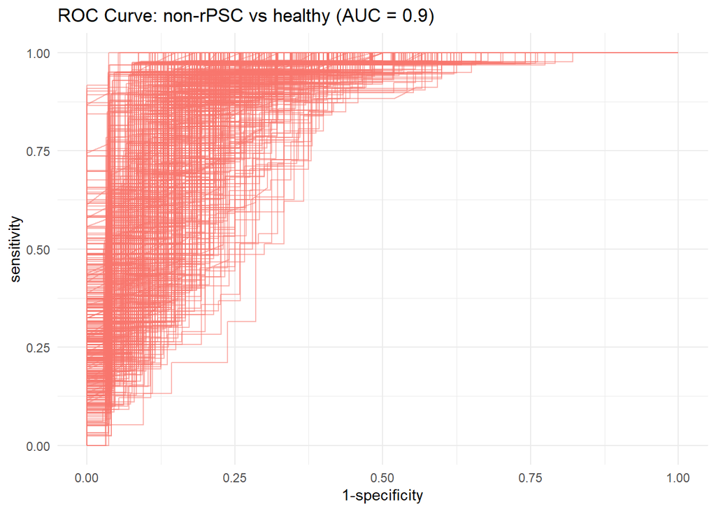

```r
roc_c
```

**rPSC effect**

```r
model_name <- paste("rPSC effect",level,segment)

# prepare the data
filt_ileum_uni_data <- binomial_prep_psc_effect(ileum_asv_tab,
                                                ileum_taxa_tab,
                                                ileum_metadata,
                                                rpsc_effect[[paste(segment,level)]],
                                                usage="ml_clr")
```

```
## Removing 1127 ASV(s)
```

```
## Removing 27 ASV(s)
```

```r
# fit the model
rf_model <- rf_binomial(filt_ileum_uni_data,
                              sample_method = "atypboot",
                              outcome="Group",
                              N=10,
                              reuse=TRUE,
                              file=model_name,
                              Q="Q2")

# ROC curve
roc_c <- roc_curve(rf_model, group)

# save the results
supplements_models[["models_summ"]][["rf_model"]][[model_name]] <- rf_model$model_summary
supplements_models[["roc_cs"]][["rf_model"]][[model_name]] <- rf_model$kfold_rocobjs

# see the results
rf_model$model_summary %>% t()
```

```
##                                 [,1]
## mtry                            "3"
## splitrule                       "gini"
## min.node.size                   "2"
## auc                             "0.9998557"
## auc_optimism_corrected          "0.5509912"
## auc_optimism_corrected_CIL      "0.3424858"
## auc_optimism_corrected_CIU      "0.6863205"
## accuracy                        "0.9927536"
## accuracy_optimism_corrected     "0.7465253"
## accuracy_optimism_corrected_CIL "0.7064338"
## accuracy_optimism_corrected_CIU "0.7869668"
```

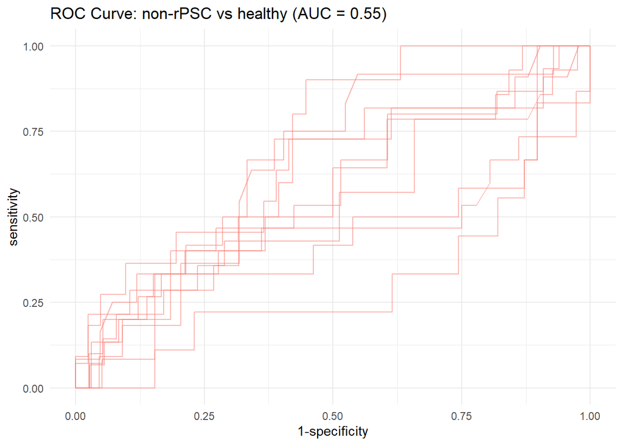

```r
roc_c
```

###### Genus level

```r
level="genus"
```

Aggregate taxa

```r
genus_data <- aggregate_taxa(ileum_asv_tab,
                             ileum_taxa_tab,
                             taxonomic_level = level)

ileum_genus_tab <- genus_data[[1]]
ileum_genus_taxa_tab <- genus_data[[2]]
```

**rPSC vs non-rPSC**

```r
group <- c("rPSC","non-rPSC")
comparison_name <- paste0(group[1], " vs ",group[2])
```

```r
model_name <- paste(comparison_name,level,segment)

# prepare the data
filt_ileum_uni_data <- binomial_prep(ileum_genus_tab,
                                     ileum_genus_taxa_tab,
                                     ileum_metadata,
                                     group,
                                     usage="ml_clr")
```

```
## Removing 55 ASV(s)
```

```
## Removing 2 ASV(s)
```

```r
# fit the model
rf_model <- rf_binomial(filt_ileum_uni_data,
                              sample_method = "atypboot",
                              outcome="Group",
                              N=10,
                              reuse=TRUE,
                              file=model_name,
                              Q="Q2")

# ROC curve
roc_c <- roc_curve(rf_model, group)

# save the results
supplements_models[["models_summ"]][["rf_model"]][[model_name]] <- rf_model$model_summary
supplements_models[["roc_cs"]][["rf_model"]][[model_name]] <- rf_model$kfold_rocobjs

# see the results
rf_model$model_summary %>% t()
```

```
##                                 [,1]
## mtry                            "137"
## splitrule                       "gini"
## min.node.size                   "2"
## auc                             "1"
## auc_optimism_corrected          "0.5766339"
## auc_optimism_corrected_CIL      "0.4064304"
## auc_optimism_corrected_CIU      "0.7448296"
## accuracy                        "1"
## accuracy_optimism_corrected     "0.7391474"
## accuracy_optimism_corrected_CIL "0.640717"
## accuracy_optimism_corrected_CIU "0.8284268"
```

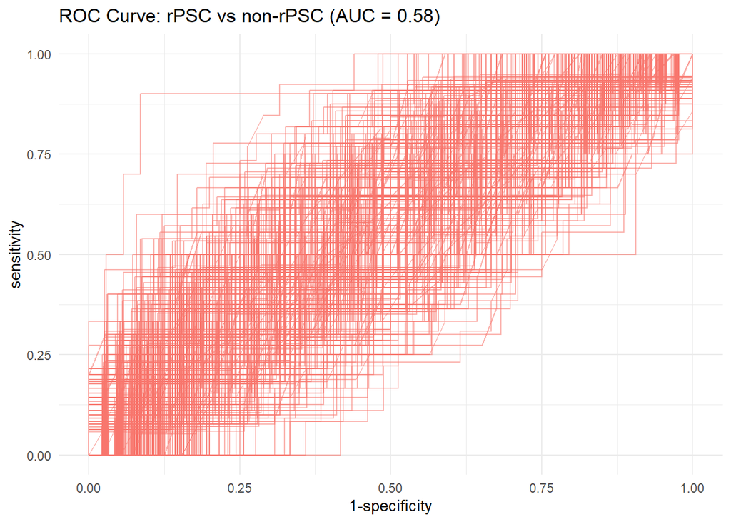

```r
roc_c
```

**rPSC vs healthy**

```r
group <- c("rPSC","healthy")
comparison_name <- paste0(group[1], " vs ",group[2])
```

```r
model_name <- paste(comparison_name,level,segment)

# prepare the data
filt_ileum_uni_data <- binomial_prep(ileum_genus_tab,
                                     ileum_genus_taxa_tab,
                                     ileum_metadata,
                                     group,
                                     usage="ml_clr")
```

```
## Removing 67 ASV(s)
```

```
## Removing 4 ASV(s)
```

```r
# fit the model
rf_model <- rf_binomial(filt_ileum_uni_data,
                              sample_method = "atypboot",
                              outcome="Group",
                              N=10,
                              reuse=TRUE,
                              file=model_name,
                              Q="Q2")

# ROC curve
roc_c <- roc_curve(rf_model, group)

# save the results
supplements_models[["models_summ"]][["rf_model"]][[model_name]] <- rf_model$model_summary
supplements_models[["roc_cs"]][["rf_model"]][[model_name]] <- rf_model$kfold_rocobjs

# see the results
rf_model$model_summary %>% t()
```

```
##                                 [,1]
## mtry                            "79"
## splitrule                       "gini"
## min.node.size                   "5"
## auc                             "1"
## auc_optimism_corrected          "0.9254174"
## auc_optimism_corrected_CIL      "0.8211377"
## auc_optimism_corrected_CIU      "0.995101"
## accuracy                        "1"
## accuracy_optimism_corrected     "0.8383844"
## accuracy_optimism_corrected_CIL "0.7142857"
## accuracy_optimism_corrected_CIU "0.9302326"
```

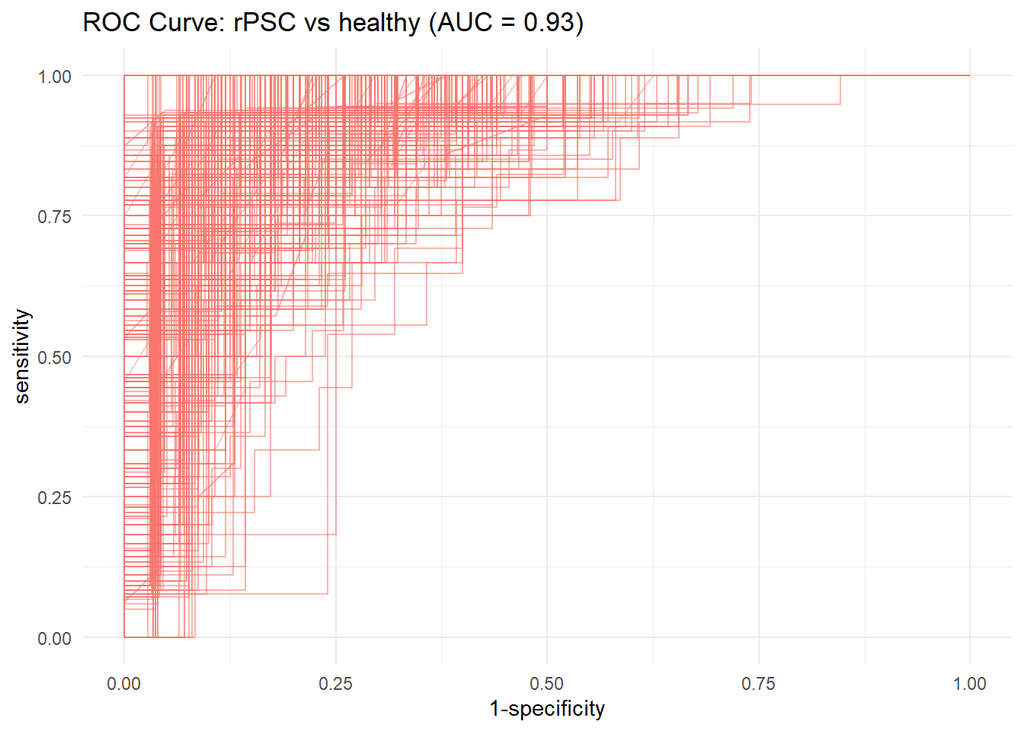

```r
roc_c
```

**non-rPSC vs healthy**

```r
group <- c("non-rPSC","healthy")
comparison_name <- paste0(group[1], " vs ",group[2])
```

```r
model_name <- paste(comparison_name,level,segment)

# prepare the data
filt_ileum_uni_data <- binomial_prep(ileum_genus_tab,
                                     ileum_genus_taxa_tab,
                                     ileum_metadata,
                                     group,
                                     usage="ml_clr")
```

```
## Removing 24 ASV(s)
```

```
## Removing 2 ASV(s)
```

```r
# fit the model
rf_model <- rf_binomial(filt_ileum_uni_data,
                              sample_method = "atypboot",
                              outcome="Group",
                              N=10,
                              reuse=TRUE,
                              file=model_name,
                              Q="Q2")

# ROC curve
roc_c <- roc_curve(rf_model, group)

# save the results
supplements_models[["models_summ"]][["rf_model"]][[model_name]] <- rf_model$model_summary
supplements_models[["roc_cs"]][["rf_model"]][[model_name]] <- rf_model$kfold_rocobjs

# see the results
rf_model$model_summary %>% t()
```

```
##                                 [,1]
## mtry                            "99"
## splitrule                       "gini"
## min.node.size                   "2"
## auc                             "1"
## auc_optimism_corrected          "0.9167953"
## auc_optimism_corrected_CIL      "0.8292326"
## auc_optimism_corrected_CIU      "0.9845504"
## accuracy                        "1"
## accuracy_optimism_corrected     "0.8603317"
## accuracy_optimism_corrected_CIL "0.7514339"
## accuracy_optimism_corrected_CIU "0.941624"
```

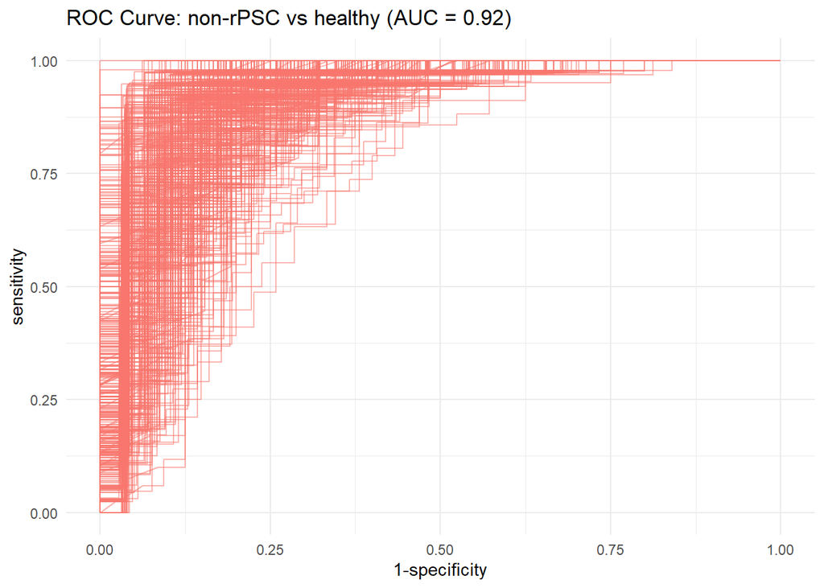

```r
roc_c
```

**rPSC effect**

```r
model_name <- paste("rPSC effect",level,segment)

# prepare the data
filt_ileum_uni_data <- binomial_prep_psc_effect(ileum_genus_tab,
                                                ileum_genus_taxa_tab,
                                                ileum_metadata,
                                                rpsc_effect[[paste(segment,level)]],
                                                usage="ml_clr")
```

```
## Removing 55 ASV(s)
```

```
## Removing 2 ASV(s)
```

```r
# fit the model
rf_model <- rf_binomial(filt_ileum_uni_data,
                              sample_method = "atypboot",
                              outcome="Group",
                              N=500,
                              reuse=TRUE,
                              file=model_name,
                              Q="Q2")

# ROC curve
roc_c <- roc_curve(rf_model, group)

# save the results
supplements_models[["models_summ"]][["rf_model"]][[model_name]] <- rf_model$model_summary
supplements_models[["roc_cs"]][["rf_model"]][[model_name]] <- rf_model$kfold_rocobjs

# see the results
rf_model$model_summary %>% t()
```

```
##                                 [,1]
## mtry                            "7"
## splitrule                       "gini"
## min.node.size                   "5"
## auc                             "1"
## auc_optimism_corrected          "0.5779119"
## auc_optimism_corrected_CIL      "0.3905371"
## auc_optimism_corrected_CIU      "0.7472356"
## accuracy                        "1"
## accuracy_optimism_corrected     "0.7424369"
## accuracy_optimism_corrected_CIL "0.6326531"
## accuracy_optimism_corrected_CIU "0.8382994"
```

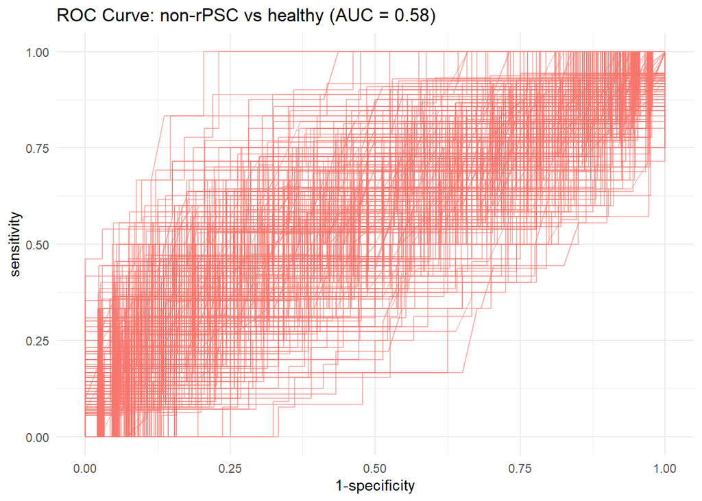

```r
roc_c
```

##### Gradient boosting

```r
model="gb"
```

###### ASV level

```r
level="ASV"
```

*rPSC vs non-rPSC*

```r
group <- c("rPSC","non-rPSC")
comparison_name <- paste0(group[1], " vs ",group[2])
```

```r
model_name <- paste(comparison_name,level,segment)

# prepare the data
filt_ileum_uni_data <- binomial_prep(ileum_asv_tab,
                                     ileum_taxa_tab,
                                     ileum_metadata,
                                     group, usage="ml_clr")
```

```
## Removing 1127 ASV(s)
```

```
## Removing 27 ASV(s)
```

```r
# fit the model
gbm_model <- gbm_binomial(filt_ileum_uni_data,
                              sample_method = "atypboot",
                              outcome="Group",
                              N=10,
                              reuse=TRUE,
                              file=model_name,
                              Q="Q2")

# ROC curve
roc_c <- roc_curve(gbm_model, group)

# save the results
supplements_models[["models_summ"]][["gbm_model"]][[model_name]] <- gbm_model$model_summary
supplements_models[["roc_cs"]][["gbm_model"]][[model_name]] <- gbm_model$kfold_rocobjs

# see the results
gbm_model$model_summary %>% t()
```

```
##                                        [,1]
## n.trees                         500.0000000
## interaction.depth                 5.0000000
## shrinkage                         0.1000000
## n.minobsinnode                   10.0000000
## auc                               1.0000000
## auc_optimism_corrected            0.5174986
## auc_optimism_corrected_CIL        0.4020749
## auc_optimism_corrected_CIU        0.6121226
## accuracy                          1.0000000
## accuracy_optimism_corrected       0.7345733
## accuracy_optimism_corrected_CIL   0.6916360
## accuracy_optimism_corrected_CIU   0.7679720
```

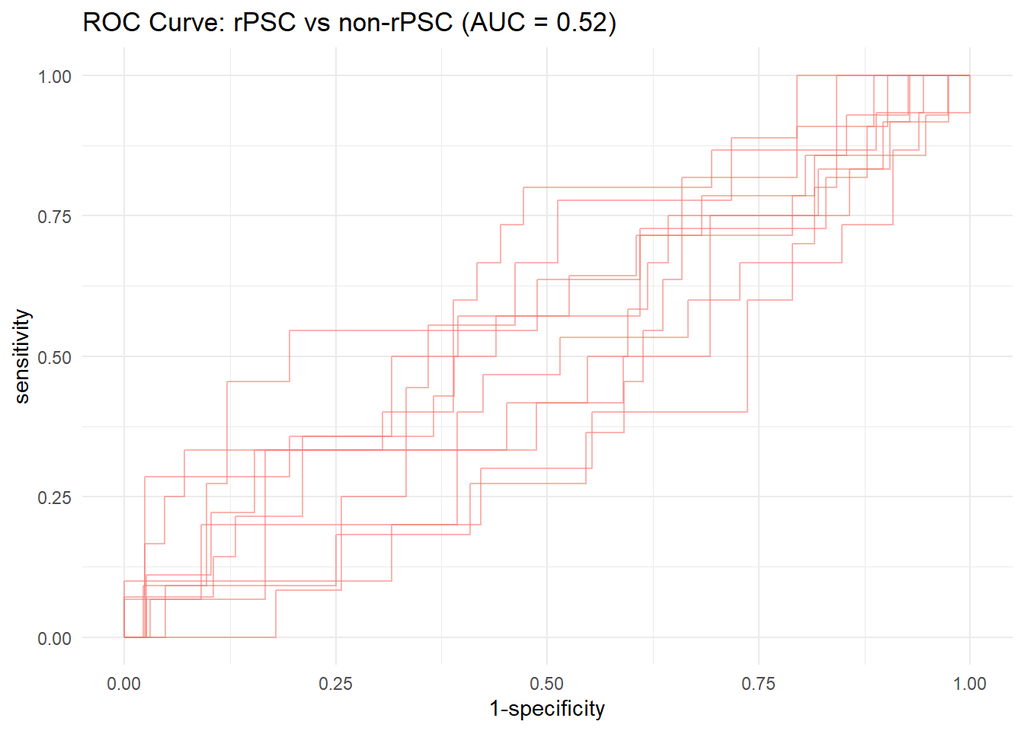

```r
roc_c
```

**rPSC vs healthy**

```r
group <- c("rPSC","healthy")
comparison_name <- paste0(group[1], " vs ",group[2])
```

```r
model_name <- paste(comparison_name,level,segment)

# prepare the data
filt_ileum_uni_data <- binomial_prep(ileum_asv_tab,
                                     ileum_taxa_tab,
                                     ileum_metadata,
                                     group, usage="ml_clr")
```

```
## Removing 1214 ASV(s)
```

```
## Removing 122 ASV(s)
```

```r
# fit the model
gbm_model <- gbm_binomial(filt_ileum_uni_data,
                              sample_method = "atypboot",
                              outcome="Group",
                              N=10,
                              reuse=TRUE,
                              file=model_name,
                              Q="Q2")

# ROC curve
roc_c <- roc_curve(gbm_model, group)

# save the results
supplements_models[["models_summ"]][["gbm_model"]][[model_name]] <- gbm_model$model_summary
supplements_models[["roc_cs"]][["gbm_model"]][[model_name]] <- gbm_model$kfold_rocobjs


# see the results
gbm_model$model_summary %>% t()
```

```
##                                        [,1]
## n.trees                         100.0000000
## interaction.depth                 3.0000000
## shrinkage                         0.1000000
## n.minobsinnode                   10.0000000
## auc                               1.0000000
## auc_optimism_corrected            0.9177655
## auc_optimism_corrected_CIL        0.8539862
## auc_optimism_corrected_CIU        0.9568388
## accuracy                          1.0000000
## accuracy_optimism_corrected       0.8083337
## accuracy_optimism_corrected_CIL   0.7415072
## accuracy_optimism_corrected_CIU   0.8709821
```

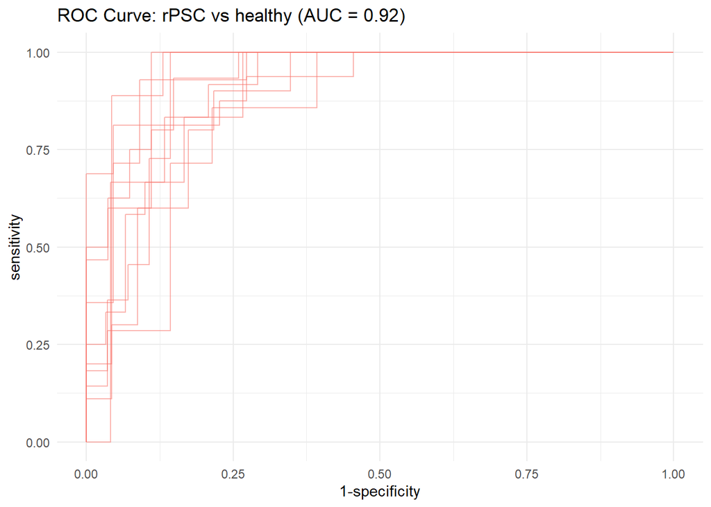

```r
roc_c
```

**non-rPSC vs healthy**

```r
group <- c("non-rPSC","healthy")
comparison_name <- paste0(group[1], " vs ",group[2])
```

```r
model_name <- paste(comparison_name,level,segment)

# prepare the data
filt_ileum_uni_data <- binomial_prep(ileum_asv_tab,
                                     ileum_taxa_tab,
                                     ileum_metadata,
                                     group, usage="ml_clr")
```

```
## Removing 392 ASV(s)
```

```
## Removing 91 ASV(s)
```

```r
# fit the model
gbm_model <- gbm_binomial(filt_ileum_uni_data,
                              sample_method = "atypboot",
                              outcome="Group",
                              N=10,
                              reuse=TRUE,
                              file=model_name,
                              Q="Q2")

# ROC curve
roc_c <- roc_curve(gbm_model, group)

# save the results
supplements_models[["models_summ"]][["gbm_model"]][[model_name]] <- gbm_model$model_summary
supplements_models[["roc_cs"]][["gbm_model"]][[model_name]] <- gbm_model$kfold_rocobjs


# see the results
gbm_model$model_summary %>% t()
```

```
##                                        [,1]
## n.trees                         500.0000000
## interaction.depth                 3.0000000
## shrinkage                         0.1000000
## n.minobsinnode                   30.0000000
## auc                               1.0000000
## auc_optimism_corrected            0.9345911
## auc_optimism_corrected_CIL        0.8675833
## auc_optimism_corrected_CIU        0.9860492
## accuracy                          1.0000000
## accuracy_optimism_corrected       0.8705655
## accuracy_optimism_corrected_CIL   0.7873572
## accuracy_optimism_corrected_CIU   0.9520161
```

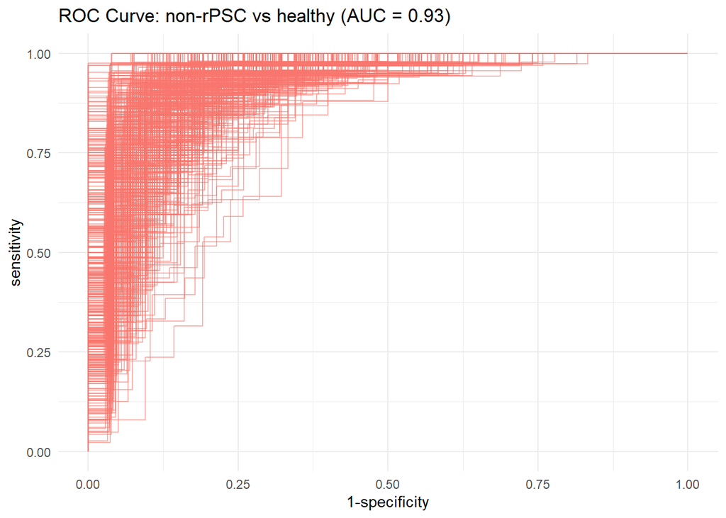

```r
roc_c
```

**rPSC effect**

```r
model_name <- paste("rPSC effect",level,segment)

# prepare the data
filt_ileum_uni_data <- binomial_prep_psc_effect(ileum_asv_tab,
                                                ileum_taxa_tab,
                                                ileum_metadata,
                                                rpsc_effect[[paste(segment,level)]],
                                                usage="ml_clr")
```

```
## Removing 1127 ASV(s)
```

```
## Removing 27 ASV(s)
```

```r
# fit the model
gbm_model <- gbm_binomial(filt_ileum_uni_data,
                              sample_method = "atypboot",
                              outcome="Group",
                              N=10,
                              reuse=TRUE,
                              file=model_name,
                              Q="Q2")

# ROC curve
roc_c <- roc_curve(gbm_model, group)

# save the results
supplements_models[["models_summ"]][["gbm_model"]][[model_name]] <- gbm_model$model_summary
supplements_models[["roc_cs"]][["gbm_model"]][[model_name]] <- gbm_model$kfold_rocobjs


# see the results
gbm_model$model_summary %>% t()
```

```
##                                        [,1]
## n.trees                         100.0000000
## interaction.depth                 1.0000000
## shrinkage                         0.1000000
## n.minobsinnode                   10.0000000
## auc                               0.9161616
## auc_optimism_corrected            0.6089129
## auc_optimism_corrected_CIL        0.4836930
## auc_optimism_corrected_CIU        0.6714232
## accuracy                          0.8550725
## accuracy_optimism_corrected       0.7623020
## accuracy_optimism_corrected_CIL   0.7121936
## accuracy_optimism_corrected_CIU   0.8241987
```

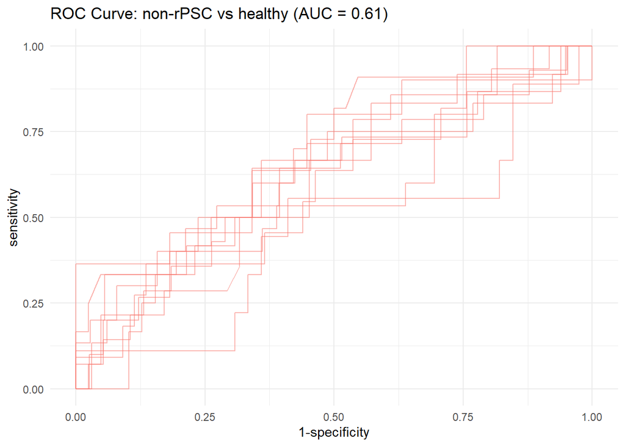

```r
roc_c
```

###### Genus level

```r
level="genus"
```

Aggregate taxa

```r
genus_data <- aggregate_taxa(ileum_asv_tab,
                             ileum_taxa_tab,
                             taxonomic_level = level)

ileum_genus_tab <- genus_data[[1]]
ileum_genus_taxa_tab <- genus_data[[2]]
```

**rPSC vs non-rPSC**

```r
group <- c("rPSC","non-rPSC")
comparison_name <- paste0(group[1], " vs ",group[2])
```

```r
model_name <- paste(comparison_name,level,segment)

# prepare the data
filt_ileum_uni_data <- binomial_prep(ileum_genus_tab,
                                     ileum_genus_taxa_tab,
                                     ileum_metadata,
                                     group,
                                     usage="ml_clr")
```

```
## Removing 55 ASV(s)
```

```
## Removing 2 ASV(s)
```

```r
# fit the model
gbm_model <- gbm_binomial(filt_ileum_uni_data,
                              sample_method = "atypboot",
                              outcome="Group",
                              N=10,
                              reuse=TRUE,
                              file=model_name,
                              Q="Q2")

# ROC curve
roc_c <- roc_curve(gbm_model, group)

# save the results
supplements_models[["models_summ"]][["gbm_model"]][[model_name]] <- gbm_model$model_summary
supplements_models[["roc_cs"]][["gbm_model"]][[model_name]] <- gbm_model$kfold_rocobjs

# see the results
gbm_model$model_summary %>% t()
```

```
##                                        [,1]
## n.trees                         200.0000000
## interaction.depth                 3.0000000
## shrinkage                         0.1000000
## n.minobsinnode                   20.0000000
## auc                               1.0000000
## auc_optimism_corrected            0.5506218
## auc_optimism_corrected_CIL        0.3970328
## auc_optimism_corrected_CIU        0.7104604
## accuracy                          1.0000000
## accuracy_optimism_corrected       0.7198110
## accuracy_optimism_corrected_CIL   0.6210556
## accuracy_optimism_corrected_CIU   0.8085106
```

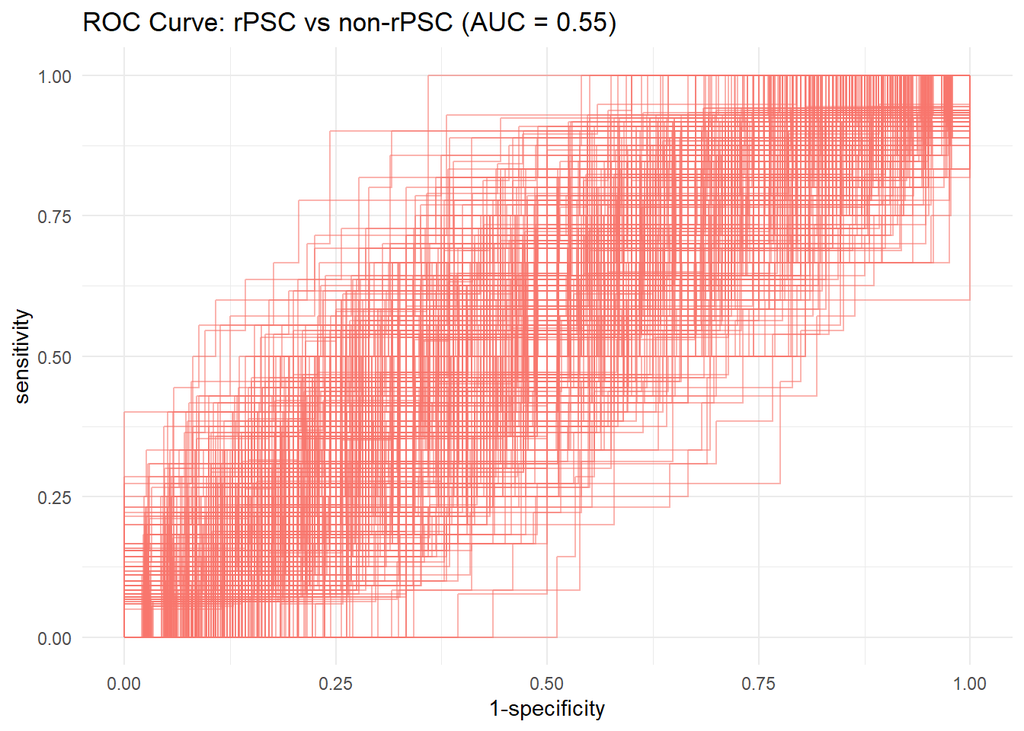

```r
roc_c
```

**rPSC vs healthy**

```r
group <- c("rPSC","healthy")
comparison_name <- paste0(group[1], " vs ",group[2])
```

```r
model_name <- paste(comparison_name,level,segment)

# prepare the data
filt_ileum_uni_data <- binomial_prep(ileum_genus_tab,
                                     ileum_genus_taxa_tab,
                                     ileum_metadata,
                                     group,
                                     usage="ml_clr")
```

```
## Removing 67 ASV(s)
```

```
## Removing 4 ASV(s)
```

```r
# fit the model
gbm_model <- gbm_binomial(filt_ileum_uni_data,
                              sample_method = "atypboot",
                              outcome="Group",
                              N=10,
                              reuse=TRUE,
                              file=model_name,
                              Q="Q2")

# ROC curve
roc_c <- roc_curve(gbm_model, group)

# save the results
supplements_models[["models_summ"]][["gbm_model"]][[model_name]] <- gbm_model$model_summary
supplements_models[["roc_cs"]][["gbm_model"]][[model_name]] <- gbm_model$kfold_rocobjs

# see the results
gbm_model$model_summary %>% t()
```

```
##                                        [,1]
## n.trees                         100.0000000
## interaction.depth                 5.0000000
## shrinkage                         0.1000000
## n.minobsinnode                   10.0000000
## auc                               1.0000000
## auc_optimism_corrected            0.9326120
## auc_optimism_corrected_CIL        0.8414615
## auc_optimism_corrected_CIU        0.9922529
## accuracy                          1.0000000
## accuracy_optimism_corrected       0.8492614
## accuracy_optimism_corrected_CIL   0.7331081
## accuracy_optimism_corrected_CIU   0.9459459
```

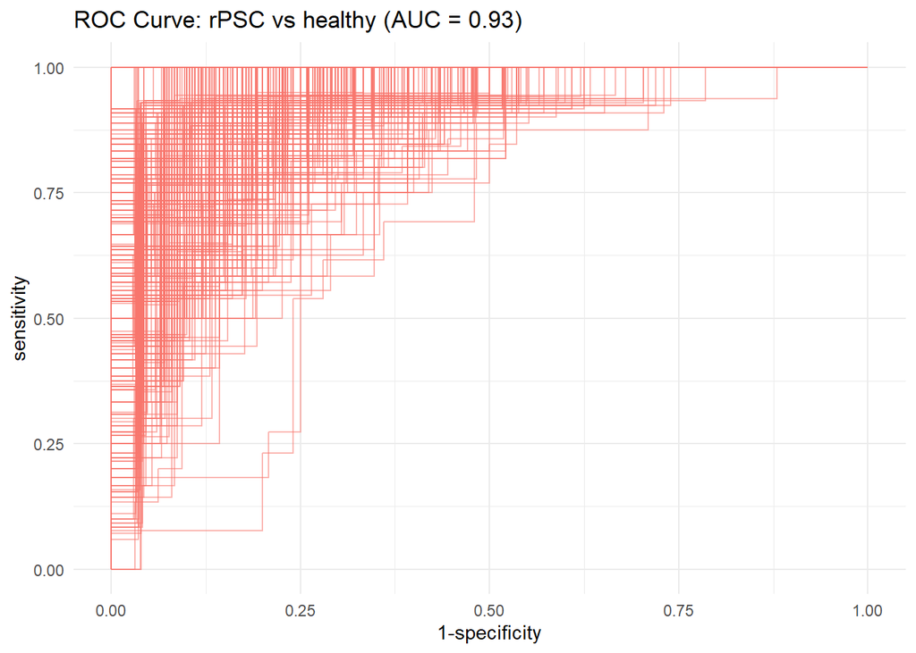

```r
roc_c
```

**non-rPSC vs healthy**

```r
group <- c("non-rPSC","healthy")
comparison_name <- paste0(group[1], " vs ",group[2])
```